# scRNA-seq Analysis Notebook

Ziyi Wang

2024-10-01

# 00.Setup environment

## 00-00. Project folder

The prerequisite data and directories structure to reproduce the results of this analysis:

```
Project Folder/
+ HTML_source/                                                                                     # CSS files for this R notebook file
+ 2D_versatile_he/                                                                                 # Pre-trained StarDist AI model
- 240726_VisiumHD/                                                                                 # 10x Visium HD output folder
  - 240726_VisiumHD/RJ_7_23_24.tif                                                                 # 10x Visium HD high resolution image
  - 240726_VisiumHD/analysis/Pax9KO/outs/binned_outputs/square_002um/filtered_feature_bc_matrix.h5 # 10x Visium HD data in 2x2 um bin
- 00.10xVisiumHDAna.Rproj                                                                          # R projection file
- 00.NIH_10xVisiumHD.html                                                                          # This R notebook file
- 3M-february-2018.txt                                                                             # 10x barcode whitelist
- E12.5.csv                                                                                        # ROIs in E12.5
- E13.5.csv                                                                                        # ROIs in E13.5
```

## 00-01.R & Conda Environment

```r
# This is a setup chunk
Sys.setenv(BASH_ENV="~/.bashrc")
knitr::opts_chunk$set(engine.opts = list(bash="--login"))
# Set enough physical memory for parallel computing
options(future.globals.maxSize= 256*1024^3)
WD <- getwd()
project <- "PAX9_KO_VisiumHD"
list.of.packages <- c("dplyr","tidyverse")
#Packages that does not install yet
new.packages <- list.of.packages[!(list.of.packages %in% installed.packages()[, "Package"])]
if(length(new.packages)) {install.packages(new.packages)}
library(dplyr)
library(tidyverse)
condaPath<-reticulate::conda_list()$python%>%
            grep("r-miniconda/envs/stardist_env",.,value=TRUE)%>%
            str_remove(.,"bin\\/python$")%>%
            paste0(.,"lib")
Sys.setenv(LD_LIBRARY_PATH=paste0(condaPath,":", Sys.getenv("LD_LIBRARY_PATH")))
PythonPath<-reticulate::conda_list()$python%>%
            grep("r-miniconda/envs/stardist_env",.,value=TRUE)
Sys.setenv(RETICULATE_PYTHON=PythonPath)
list.of.packages <- c("reticulate")
#Packages that does not install yet
new.packages <- list.of.packages[!(list.of.packages %in% installed.packages()[, "Package"])]
if(length(new.packages)) {install.packages(new.packages)}
library(reticulate)
use_condaenv("stardist_env", required = TRUE)
polychrome = c(
  "#5A5156", "#E4E1E3", "#F6222E", "#FE00FA", "#16FF32", "#3283FE",
  "#FEAF16", "#B00068", "#1CFFCE", "#90AD1C", "#2ED9FF", "#DEA0FD",
  "#AA0DFE", "#F8A19F", "#325A9B", "#C4451C", "#1C8356", "#85660D",
  "#B10DA1", "#FBE426", "#1CBE4F", "#FA0087", "#FC1CBF", "#F7E1A0",
  "#C075A6", "#782AB6", "#AAF400", "#BDCDFF", "#822E1C", "#B5EFB5",
  "#7ED7D1", "#1C7F93", "#D85FF7", "#683B79", "#66B0FF", "#3B00FB"
)
# Install & load dependent R packages
list.of.packages <- c(
  "R.utils","data.table","Seurat","tidyr","Matrix", "patchwork", "ggplotify",
  "grid","gridExtra","rmarkdown","htmltools","plyr","plotly","htmlTable","magrittr","xml2", "hdf5r",
  "openxlsx", "ggplot2","RColorBrewer", "cowplot", "Polychrome", "htmlwidgets",
  "stringr", "hwriter", "writexl", "arrow", "magick"
)
list.of.packages.Bio <- c(
  "GSVA","survcomp","SingleCellExperiment", "ggtreeExtra", "AnnotationHub"
)
#Packages that does not install yet
new.packages <- list.of.packages[!(list.of.packages %in% installed.packages()[, "Package"])]
new.packages.Bio <- list.of.packages.Bio[!(list.of.packages.Bio %in% installed.packages()[, "Package"])]
#install required packages
if (!requireNamespace("BiocManager", quietly = TRUE)){install.packages("BiocManager")}
if(length(new.packages.Bio)) {BiocManager::install(new.packages.Bio)}
if(length(new.packages)) {install.packages(new.packages)}
#Set GitHub Auth
#https://usethis.r-lib.org/articles/git-credentials.html
if (!requireNamespace("remotes", quietly = TRUE)) {
  install.packages("remotes")
}
if (!require(biomaRt)) devtools::install_github("grimbough/biomaRt")
```

```r
if (!require(SeuratWrappers)) devtools::install_github('satijalab/seurat-wrappers')
if (!require(viridis)) install.packages("viridis")
if (!require(readr)) install.packages("readr")
if (!require(phateR)) install.packages("phateR")
if (!require(sceasy)) devtools::install_github("cellgeni/sceasy")
if (!require(SeuratDisk)) remotes::install_github("mojaveazure/seurat-disk")
# Loading all packages
invisible(
  lapply(
    c(
      list.of.packages,list.of.packages.Bio, "phateR","readr","viridis","biomaRt","SeuratWrappers","SeuratDisk"
    ),
    library, character.only = TRUE
  )
)
```

[output not shown]

## 00-02.Python Environment

Important Python Libraries

- `stardist` is a deep-learning library for star-convex object detection of cells/nuclei.
- `geopandas` is an extension of the pandas library for working with geospatial data.
- `squidpy` is a collection of tools that are built on scanpy and anndata for the visualization and analysis of spatial gene expression data. It is used in this guide mainly for the scanpy and anndata libraries.
- `fastparquet` is a Python library for efficient reading and writing of Apache Parquet files.

```python
reticulate::repl_python()
import pandas as pd
import numpy as np
import matplotlib.pyplot as plt
import anndata
import geopandas as gpd
import scanpy as sc

from tifffile import imread, imwrite
from csbdeep.utils import normalize
from stardist.models import StarDist2D
```

[output not shown]

[output not shown]

```
2024-10-11 22:36:51.699804: W tensorflow/compiler/tf2tensorrt/utils/py_utils.cc:38] TF-TRT Warning: Could not find TensorRT
```

```python
from shapely.geometry import Polygon, Point
from scipy import sparse
from matplotlib.colors import ListedColormap

import pickle
def get_picklable_objects(namespace):
    picklable = {}
    for name, obj in namespace.items():
        try:
            pickle.dumps(obj)
            picklable[name] = obj
        except (pickle.PicklingError, TypeError):
            continue
    return picklable
```

Data Visualization Helper Functions: We define functions to help with plotting results in the next code block.

```python
# General image plotting functions
def plot_mask_and_save_image(title, gdf, img, cmap, output_name=None, bbox=None):
    if bbox is not None:
        # Crop the image to the bounding box
        cropped_img = img[bbox[1]:bbox[3], bbox[0]:bbox[2]]
    else:
        cropped_img = img

    # Plot options
    fig, axes = plt.subplots(1, 2, figsize=(12, 6))

    # Plot the cropped image
    axes[0].imshow(cropped_img, cmap='gray', origin='lower')
    axes[0].set_title(title)
    axes[0].axis('off')

    # Create filtering polygon
    if bbox is not None:
        bbox_polygon = Polygon([(bbox[0], bbox[1]), (bbox[2], bbox[1]), (bbox[2], bbox[3]), (bbox[0], bbox[3])])
        # Filter for polygons in the box
        intersects_bbox = gdf['geometry'].intersects(bbox_polygon)
        filtered_gdf = gdf[intersects_bbox]
    else:
        filtered_gdf=gdf

    # Plot the filtered polygons on the second axis
    filtered_gdf.plot(cmap=cmap, ax=axes[1])
    axes[1].axis('off')
    axes[1].legend(loc='upper left', bbox_to_anchor=(1.05, 1))


    # Save the plot if output_name is provided
    if output_name is not None:
        plt.savefig(output_name, bbox_inches='tight')  # Use bbox_inches='tight' to include the legend
    else:
        plt.show()

def plot_gene_and_save_image(title, gdf, gene, img, adata, bbox=None, output_name=None):

    if bbox is not None:
        # Crop the image to the bounding box
        cropped_img = img[bbox[1]:bbox[3], bbox[0]:bbox[2]]
    else:
        cropped_img = img

    # Plot options
    fig, axes = plt.subplots(1, 2, figsize=(12, 6))

    # Plot the cropped image
    axes[0].imshow(cropped_img, cmap='gray', origin='lower')
    axes[0].set_title(title)
    axes[0].axis('off')

    # Create filtering polygon
    if bbox is not None:
        bbox_polygon = Polygon([(bbox[0], bbox[1]), (bbox[2], bbox[1]), (bbox[2], bbox[3]), (bbox[0], bbox[3])])


    # Find a gene of interest and merge with the geodataframe
    gene_expression = adata[:, gene].to_df()
    gene_expression['id'] = gene_expression.index
    merged_gdf = gdf.merge(gene_expression, left_on='id', right_on='id')

    if bbox is not None:
        # Filter for polygons in the box
        intersects_bbox = merged_gdf['geometry'].intersects(bbox_polygon)
        filtered_gdf = merged_gdf[intersects_bbox]
    else:
        filtered_gdf = merged_gdf

    # Plot the filtered polygons on the second axis
    filtered_gdf.plot(column=gene, cmap='inferno', legend=True, ax=axes[1])
    axes[1].set_title(gene)
    axes[1].axis('off')
    axes[1].legend(loc='upper left', bbox_to_anchor=(1.05, 1))

    # Save the plot if output_name is provided
    if output_name is not None:
        plt.savefig(output_name, bbox_inches='tight')  # Use bbox_inches='tight' to include the legend
    else:
        plt.show()

def plot_clusters_and_save_image(title, gdf, img, adata, bbox=None, color_by_obs=None, output_name=None, color_list=None):
    color_list=["#7f0000","#808000","#483d8b","#008000","#bc8f8f","#008b8b","#4682b4","#000080","#d2691e","#9acd32","#8fbc8f","#800080","#b03060","#ff4500","#ffa500","#ffff00","#00ff00","#8a2be2","#00ff7f","#dc143c","#00ffff","#0000ff","#ff00ff","#1e90ff","#f0e68c","#90ee90","#add8e6","#ff1493","#7b68ee","#ee82ee"]
    if bbox is not None:
        cropped_img = img[bbox[1]:bbox[3], bbox[0]:bbox[2]]
    else:
        cropped_img = img

    fig, axes = plt.subplots(1, 2, figsize=(12, 6))

    axes[0].imshow(cropped_img, cmap='gray', origin='lower')
    axes[0].set_title(title)
    axes[0].axis('off')

    if bbox is not None:
        bbox_polygon = Polygon([(bbox[0], bbox[1]), (bbox[2], bbox[1]), (bbox[2], bbox[3]), (bbox[0], bbox[3])])

    unique_values = adata.obs[color_by_obs].astype('category').cat.categories
    num_categories = len(unique_values)

    if color_list is not None and len(color_list) >= num_categories:
        custom_cmap = ListedColormap(color_list[:num_categories], name='custom_cmap')
    else:
        # Use default tab20 colors if color_list is insufficient
        tab20_colors = plt.cm.tab20.colors[:num_categories]
        custom_cmap = ListedColormap(tab20_colors, name='custom_tab20_cmap')

    merged_gdf = gdf.merge(adata.obs[color_by_obs].astype('category'), left_on='id', right_index=True)

    if bbox is not None:
        intersects_bbox = merged_gdf['geometry'].intersects(bbox_polygon)
        filtered_gdf = merged_gdf[intersects_bbox]
    else:
        filtered_gdf = merged_gdf

    # Plot the filtered polygons on the second axis
    plot = filtered_gdf.plot(column=color_by_obs, cmap=custom_cmap, ax=axes[1], legend=True)
    axes[1].set_title(color_by_obs)
    legend = axes[1].get_legend()
    legend.set_bbox_to_anchor((1.05, 1))
    axes[1].axis('off')

    # Move legend outside the plot
    plot.get_legend().set_bbox_to_anchor((1.25, 1))

    if output_name is not None:
        plt.savefig(output_name, bbox_inches='tight')
    else:
        plt.show()

# Plotting function for nuclei area distribution
def plot_nuclei_area(gdf,area_cut_off):
    fig, axs = plt.subplots(1, 2, figsize=(15, 4))
    # Plot the histograms
    axs[0].hist(gdf['area'], bins=50, edgecolor='black')
    axs[0].set_title('Nuclei Area')

    axs[1].hist(gdf[gdf['area'] < area_cut_off]['area'], bins=50, edgecolor='black')
    axs[1].set_title('Nuclei Area Filtered:'+str(area_cut_off))

    plt.tight_layout()
    plt.show()

# Total UMI distribution plotting function
def total_umi(adata_, cut_off):
    fig, axs = plt.subplots(1, 2, figsize=(12, 4))

    # Box plot
    axs[0].boxplot(adata_.obs["total_counts"], vert=False, widths=0.7, patch_artist=True, boxprops=dict(facecolor='skyblue'))
    axs[0].set_title('Total Counts')

    # Box plot after filtering
    axs[1].boxplot(adata_.obs["total_counts"][adata_.obs["total_counts"] > cut_off], vert=False, widths=0.7, patch_artist=True, boxprops=dict(facecolor='skyblue'))
    axs[1].set_title('Total Counts > ' + str(cut_off))

    # Remove y-axis ticks and labels
    for ax in axs:
        ax.get_yaxis().set_visible(False)

    plt.tight_layout()
    plt.show()
```

## 00-03.Online Resources

Retrieve internet resources for functional enrichment analysis (FEA).

```r
quit
## Get bioMart database list ----
SpeciesLs <- NULL
attempt <- 1
attempt_max <- 12
while (is.null(SpeciesLs) && attempt < 13) {
  if (attempt %in% seq(from = 1, to = attempt_max, 3)) {
    url <- "https://www.ensembl.org"
  } else if (attempt %in% seq(from = 2, to = attempt_max, 3)) {
    url <- "https://asia.ensembl.org"
  } else if (attempt %in% seq(from = 3, to = attempt_max, 3)) {
    url <- "https://uswest.ensembl.org/"
  } else if (attempt %in% seq(from = 4, to = attempt_max, 3)) {
    url <- "https://useast.ensembl.org/"
  }
  try({
    SpeciesLs <- useMart("ENSEMBL_MART_ENSEMBL", host = url) %>%
      biomaRt::listDatasets(mart = .) %>% as.data.frame()
  })
}
## Get KEGG organism list ----
KEGGSpeciesLs<-NULL
attemp<-1
while (is.null(KEGGSpeciesLs) && attemp<10) {
  url <- "https://rest.kegg.jp/list/organism"
  lines <- readLines(url)
  split <- strsplit(lines, "\t")
  u <- unlist(split)
  KEGGSpeciesLs <- matrix(u, ncol=4, byrow=TRUE)
  colnames(KEGGSpeciesLs) <-  c("T.number", "organism", "species", "phylogeny")
  KEGGSpeciesLs<-as.data.frame(KEGGSpeciesLs)
  attemp<-attemp+1
}
## Find overlapped between KEGG and BioMart ----
## as the organism list for our software
Species_BioMart<-SpeciesLs$description %>%
  str_remove_all(., " genes \\(.*\\)$")
Species_KEGG<-KEGGSpeciesLs$species %>%
  str_extract_all(., "\\(.*\\)$")
KEGGSpeciesLs<-KEGGSpeciesLs[
  !(lapply(Species_KEGG, is_empty)%>%unlist()),
]
SpeciesLs<-cbind(
  SpeciesLs,SpeciesName=Species_BioMart%>%tolower()
)
KEGGSpeciesLs<-cbind(
  KEGGSpeciesLs,
  SpeciesName=Species_KEGG%>%unlist()%>%
    str_remove_all(.,"[\\(\\)]")%>%tolower()
)
KEGGSpeciesLs$SpeciesName[KEGGSpeciesLs$SpeciesName=="house mouse"]<-"mouse"
SpeLsIntersect<-intersect(SpeciesLs$SpeciesName, KEGGSpeciesLs$SpeciesName)
KEGGSpeciesLs<-KEGGSpeciesLs[
  KEGGSpeciesLs$SpeciesName%in%SpeLsIntersect,
]
SpeciesLs<-SpeciesLs[
  SpeciesLs$SpeciesName%in%SpeLsIntersect,
]
OrgList<-merge(KEGGSpeciesLs, SpeciesLs, by="SpeciesName")
rownames(OrgList)<-OrgList$description
SpeciesLs<-rownames(OrgList)
rm(KEGGSpeciesLs,SpeLsIntersect,Species_KEGG,Species_BioMart)
setAnnotationHubOption("CACHE", file.path(".", "02.Cache"))
OrgDb_ls <- BiocManager::available() %>% grep("^org\\..*\\.eg\\.db$", ., value = TRUE)
```

```
'getOption("repos")' replaces Bioconductor standard repositories, see 'help("repositories", package = "BiocManager")' for
details.
Replacement repositories:
    CRAN: https://cran.rstudio.com/
```

```r
R.utils::setOption("clusterProfiler.download.method", "wget")
```

## 00-04.Additional environments

```r
# install dependencies
if(!require("hdf5r")){install.packages("hdf5r")}
if(!require("Seurat")){install.packages("Seurat")}
if(!require("SeuratObject")){install.packages("SeuratObject")}
if(!require("SeuratDisk")){remotes::install_github("mojaveazure/seurat-disk")}
# install platform specific source package
if (!require("loupeR")){
  os <- sub("Darwin", "macOS", Sys.info()["sysname"])
  url <- paste0("https://github.com/10XGenomics/loupeR/releases/latest/download/loupeR_", os, ".tar.gz")
  install.packages(url, repos = NULL, type = "source")
  loupeR::setup()
}
library(hdf5r)
library(Seurat)
library(SeuratObject)
library(SeuratDisk)
library(loupeR)
library(gtools)
```

## 00-05. Load functions

### Make function to list all 10x TSV files (scRNAseq, Visium, and Xenium).

```r
Find10xTSV <- function(WD){
  Path_Sep <- file.path("a","a") %>% str_remove_all("a")
  TSVmeta <- setNames(data.frame(matrix(ncol = 3, nrow = 0)), c("ID","Path", "Type"))
  fls <- list.files(
    path = WD, pattern = "barcodes.tsv.gz",
    full.names = TRUE, all.files = FALSE, recursive = TRUE
  )
  temp <- fls %>%
    .[!.[]%in%grep("raw_feature_bc_matrix",.,value = TRUE)]%>%
    .[!.[]%in%grep("SC_RNA_COUNTER_CS",.,value = TRUE)] %>%
    grep("/(count|outs|cell_feature_matrix)/", ., value = TRUE) %>%
    {
      c(
        .,
        fls %>% str_remove_all(., WD) %>%
          str_remove_all(., "barcodes.tsv.gz$") %>%
          str_split(., "\\/") %>%
          {fls[which(unlist(lapply(., length)) == 3)]} %>%
          lapply(., function(x){return(tail(x,2)[1])}) %>%
          unlist()
      )
    }
  for (path in temp) {
    row <- c(path)
    path <- sub(WD,"",path) %>% dirname()
    while (dirname(path) != "/") {
      path <- dirname(path)
    }
    ID <- basename(path)
    path <- file.path(WD, basename(path))
    test <- list.files(
      path = path, pattern = "morphology.ome.tif|morphology_focus.ome.tif|morphology_mip.ome.tif",
      full.names = TRUE, all.files = FALSE, recursive = TRUE
    )
    Type <- NULL
    if(!is_empty(test)&is.null(Type)){
      Type <- "Xenium"
      test <-character(0)
    }else{
      test <- list.files(
        path = path, pattern = "aligned_fiducials.jpg|detected_tissue_image.jpg|scalefactors_json.json|tissue_hires_image.png|tissue_lowres_image.png|tissue_positions_list.csv",
        full.names = TRUE, all.files = FALSE, recursive = TRUE
      )
    }
    if(!is_empty(test)&is.null(Type)){
      Type <- "Visum"
      test <-character(0)
    }else{
      test <- "other"
    }
    if(!is_empty(test)&is.null(Type)){
      Type <- "scRNAseq"
      rm(test)
    }
    TSVmeta[which(temp%in%row[1]),] <- c(ID, row%>%str_remove_all(.,"barcodes.tsv.gz"), Type)
  }
  rownames(TSVmeta)<-TSVmeta$ID
  return(TSVmeta)
}
```

### Make functions to convert 10x TSV files into Seurat object.

```r
Zenium_TSV2Seurat <- function(TSVmeta, WD){
  if(!file.exists(file.path(WD, "01.PlotOutput"))){
    dir.create(file.path(WD, "01.PlotOutput"))
  }
  outsum<-data.frame()
  ID_mapping<-data.frame(
    ensemblID=NULL,
    GeneSymbol=NULL,
    Type=NULL
  )
  SampleSlt<-TSVmeta$ID
  Step1_resume<-FALSE
  for (i in 1:length(SampleSlt)) {
    print(paste0(Sys.time(), ": Processing ", SampleSlt[i]))
    # Load the dataset
    temp<-read_tsv(gzfile(file.path(TSVmeta[SampleSlt[i],"Path"],"features.tsv.gz")),
                   col_names = c("ensemblID", "GeneSymbol","Type"))
    if(ncol(temp) < 2){
      temp <- cbind(
        temp, temp,
        type = "Gene Expression"
      )
      colnames(temp) <- c("ensemblID", "GeneSymbol", "Type")
      temp$ensemblID <- temp$ensemblID %>% str_remove(., "^.*_")
      temp$GeneSymbol <- temp$GeneSymbol %>% str_remove(., "^.*_")
      write_tsv(
        temp, file = file.path(TSVmeta[SampleSlt[i],"Path"],"features.tsv"),
        col_names = FALSE
      )
      gzip(file.path(TSVmeta[SampleSlt[i],"Path"],"features.tsv"), overwrite = TRUE)
    }else if(ncol(temp) < 3){
      temp <- cbind(
        temp,
        Type = "Gene Expression"
      )
      temp$ensemblID <- temp$ensemblID %>% str_remove(., "^.*_")
      temp$GeneSymbol <- temp$GeneSymbol %>% str_remove(., "^.*_")
      write_tsv(
        temp, file = file.path(TSVmeta[SampleSlt[i],"Path"],"features.tsv"),
        col_names = FALSE
      )
      gzip(file.path(TSVmeta[SampleSlt[i],"Path"],"features.tsv"), overwrite = TRUE)
    }
    ID_mapping<-rbind(
      ID_mapping,
      temp[!temp$ensemblID%in%ID_mapping$ensemblID,]
    )
    rm(temp)
    if( (!file.exists(paste0(".//Raw.",SampleSlt[i],".rds"))) | (!Step1_resume) ){
      print(paste0("Processing ", SampleSlt[i], ": Routine processing"))
      if(TSVmeta$Type[i]=="Xenium"){
        step <- "Before"
        xenium.obj <- LoadXenium(dirname(TSVmeta$Path[i]), fov = SampleSlt[i])
        xenium.obj <- subset(xenium.obj, subset = nCount_Xenium > 0)
        xenium.obj@meta.data$orig.ident <- factor(x = rep(SampleSlt[i], ncol(xenium.obj)), levels = SampleSlt[i])
        dims <- round(min(ncol(xenium.obj),nrow(xenium.obj))/3)
        xenium.obj <- SCTransform(xenium.obj, assay = "Xenium")
        # Identify the 10 most highly variable genes
        top10 <- head(VariableFeatures(xenium.obj), 10)
        # plot variable features with and without labels
        plot1 <- VariableFeaturePlot(xenium.obj)
        plot2 <- LabelPoints(plot = plot1, points = top10, repel = TRUE)
        png(
          filename = file.path(WD, "01.PlotOutput", paste0(SampleSlt[i],".03.",step,"DoubletRemove.VariableFeatures.png")),
          width = 1600, height = 900
        )
        print(plot1 + plot2)
        dev.off()
        xenium.obj <- RunPCA(xenium.obj, npcs = dims, features = rownames(xenium.obj))
        # Examine and visualize PCA results a few different ways
        print(xenium.obj[["pca"]], dims = 1:5, nfeatures = 5)
        plot<-VizDimLoadings(xenium.obj, dims = 1:2, reduction = "pca")
        png(
          filename = file.path(WD, "01.PlotOutput", paste0(SampleSlt[i],".04.1.",step,"DoubletRemove.PCA_Res1.png")),
          width = 1600, height = 900
        )
        print(plot)
        dev.off()
        plot<-DimPlot(xenium.obj, reduction = "pca")
        png(
          filename = file.path(WD, "01.PlotOutput", paste0(SampleSlt[i],".04.2.",step,"DoubletRemove.PCA_Res2.png")),
          width = 1600, height = 900
        )
        print(plot)
        dev.off()
        if(ncol(xenium.obj)<500){
          cells<-ncol(xenium.obj)
        }else{
          cells<-500
        }
        png(
          filename = file.path(WD, "01.PlotOutput", paste0(SampleSlt[i],".04.3.",step,"DoubletRemove.PCA_Heatmap1.png")),
          width = 1600, height = 900
        )
        DimHeatmap(xenium.obj, dims = 1, cells = cells, balanced = TRUE)
        dev.off()
        if(ncol(xenium.obj)<15){
          dimsupper<-ncol(xenium.obj)-1
        }else{
          dimsupper<-15
        }
        png(
          filename = file.path(WD, "01.PlotOutput", paste0(SampleSlt[i],".04.4.",step,"DoubletRemove.PCA_Heatmap2.png")),
          width = 1600, height = 900
        )
        DimHeatmap(xenium.obj, dims = 1:dimsupper, cells = cells, balanced = TRUE)
        dev.off()
        Cutdim <- xenium.obj@reductions[["pca"]]@stdev%>%
          .[.>mean(.)]%>%length()
        if(ncol(xenium.obj)<50){
          plot2<-ElbowPlot(xenium.obj, ndims = ncol(xenium.obj)-1)
        }else{
          plot2<-ElbowPlot(xenium.obj, ndims = 50)
        }
        png(
          filename = file.path(
            WD, "01.PlotOutput", paste0(SampleSlt[i],".05.",step,"DoubletRemove.JackStraw_Elbow_cutDim_",Cutdim,"_.png")
          ),
          width = 1600, height = 900
        )
        print(plot2)
        dev.off()
        xenium.obj <- RunUMAP(xenium.obj, dims = 1:Cutdim)
        xenium.obj <- FindNeighbors(xenium.obj, reduction = "pca", dims = 1:Cutdim)
        xenium.obj <- FindClusters(xenium.obj, resolution = 0.3)
        print( paste0("Processing ", SampleSlt[i], ": Making Plots"))
        plot<-DimPlot(xenium.obj, reduction = "umap", cols = "polychrome")
        png(
          filename = file.path(WD, "01.PlotOutput", paste0(SampleSlt[i],".06.",step,"DoubletRemove.Cluster.png")),
          width = 1600, height = 900
        )
        print(plot)
        dev.off()
        # Visualize QC metrics as a violin plot
        plot<-VlnPlot(xenium.obj, features = c("nFeature_Xenium", "nCount_Xenium"), ncol = 2)
        png(
          filename = file.path(WD, "01.PlotOutput", paste0(SampleSlt[i],".01.",step,"DoubletRemove.FeatureVolin.split.png")),
          width = 1600, height = 900
        )
        print(plot)
        dev.off()
        plot<-VlnPlot(xenium.obj, features = c("nFeature_Xenium", "nCount_Xenium"), ncol = 2, group.by = "orig.ident")
        png(
          filename = file.path(WD, "01.PlotOutput", paste0(SampleSlt[i],".01.",step,"DoubletRemove.FeatureVolin.stack.png")),
          width = 1600, height = 900
        )
        print(plot)
        dev.off()
        # FeatureScatter is typically used to visualize feature-feature relationships, but can be used
        # for anything calculated by the object, i.e. columns in object metadata, PC scores etc.
        plot1 <- FeatureScatter(xenium.obj, feature1 = "nCount_Xenium", feature2 = "nFeature_Xenium")
        png(
          filename = file.path(WD, "01.PlotOutput", paste0(SampleSlt[i],".02.",step,"DoubletRemove.FeatureScatter.png")),
          width = 1600, height = 900
        )
        print(plot1)
        dev.off()
        graphics.off()
        gc()
        graphics.off()
        p0<-ImageDimPlot(
          xenium.obj, group.by = "seurat_clusters", size = 0.4, cols = "polychrome", dark.background = F
        ) + ggtitle("Seurat Clusters")
        p1<-DimPlot(xenium.obj, cols = "polychrome")
        p2<-FeaturePlot(xenium.obj, pt.size = 1, features = "nFeature_Xenium", slot = "data", min.cutoff = NA, max.cutoff = NA, keep.scale=NULL)+
          labs(title = paste0("# of Gene of each cell in ",SampleSlt[i]))
        p3<-FeaturePlot(xenium.obj, pt.size = 1, features = "nCount_Xenium", slot = "data", min.cutoff = NA, max.cutoff = NA, keep.scale=NULL)+
          labs(title = paste0("# of Reads of each cell in ",SampleSlt[i]))
        png(
          filename = file.path(
            WD, "01.PlotOutput", paste0(SampleSlt[i], ".00.BeforeDoubletRemove.DimPlot.png")
          ),
          width = 1200, height = 1000
        )
        grid.arrange(p0, p1, p2, p3, nrow=2, top = paste0("Feature Distribution in: ",SampleSlt[i]))
        dev.off()
        graphics.off()
        print(paste0("Processing ", SampleSlt[i], ": Saving"))
        saveRDS(
          xenium.obj, file = file.path(
            WD,
            paste0("Raw.", SampleSlt[i], ".rds")
          )
        )
        rm(xenium.obj)
        gc()
      }else{
        print(paste0(Sys.time(), ": ", SampleSlt[i]), " is not Xenium Data.")
      }
    }else{
      print(paste0(Sys.time(), ": Skip ", SampleSlt[i], "- Found previous results"))
    }
  }
  save(outsum, ID_mapping, file=file.path(WD, "Parameters.RData"))
}
```

### Make functions for gene ID conversion and functional enrichment analysis (FEA).

```r
Symbol2Ensembl_BioMat <- function(dataset = "mmusculus_gene_ensembl", GeneName){
  ensembl_gene_id <- NULL
  attempt <- 1
  attempt_max <- 12
  while (is.null(ensembl_gene_id) && attempt < 13) {
    if (attempt %in% seq(from = 1, to = attempt_max, 3)) {
      url <- "https://www.ensembl.org"
    } else if (attempt %in% seq(from = 2, to = attempt_max, 3)) {
      url <- "https://asia.ensembl.org"
    } else if (attempt %in% seq(from = 3, to = attempt_max, 3)) {
      url <- "https://uswest.ensembl.org/"
    } else if (attempt %in% seq(from = 4, to = attempt_max, 3)) {
      url <- "https://useast.ensembl.org/"
    }
    try({
      ensembl_gene_id <- getBM(
        mart = useDataset(dataset,useMart("ENSEMBL_MART_ENSEMBL", host = url)),
        attributes = c("ensembl_gene_id","entrezgene_id","gene_biotype",
                       "external_gene_name","description"),
        filter = "external_gene_name",
        values = GeneName,
        uniqueRows = TRUE)
    })
    attempt <- attempt + 1
    Sys.sleep(0.25)
  }
  return(ensembl_gene_id)
}
Entrez2Ensembl_BioMat <- function(dataset = "mmusculus_gene_ensembl", entrezgene_id){
  ensembl_gene_id <- NULL
  attempt <- 1
  attempt_max <- 12
  while (is.null(ensembl_gene_id) && attempt < 13) {
    if (attempt %in% seq(from = 1, to = attempt_max, 3)) {
      url <- "https://www.ensembl.org"
    } else if (attempt %in% seq(from = 2, to = attempt_max, 3)) {
      url <- "https://asia.ensembl.org"
    } else if (attempt %in% seq(from = 3, to = attempt_max, 3)) {
      url <- "https://uswest.ensembl.org/"
    } else if (attempt %in% seq(from = 4, to = attempt_max, 3)) {
      url <- "https://useast.ensembl.org/"
    }
    try({
      ensembl_gene_id <- getBM(
        mart = useDataset(dataset,useMart("ENSEMBL_MART_ENSEMBL", host = url)),
        attributes = c("ensembl_gene_id","entrezgene_id","gene_biotype",
                       "external_gene_name","description"),
        filter = "entrezgene_id",
        values = entrezgene_id,
        uniqueRows = TRUE)
    })
    attempt <- attempt + 1
    Sys.sleep(0.25)
  }
  return(ensembl_gene_id)
}
RetrieveEnsembl_BioMat <- function(dataset = "mmusculus_gene_ensembl", ensembl_gene_id){
  RetrieveEnsembl <- NULL
  attempt <- 1
  attempt_max <- 12
  while (is.null(RetrieveEnsembl) && attempt < 13) {
    if (attempt %in% seq(from = 1, to = attempt_max, 3)) {
      url <- "https://www.ensembl.org"
    } else if (attempt %in% seq(from = 2, to = attempt_max, 3)) {
      url <- "https://asia.ensembl.org"
    } else if (attempt %in% seq(from = 3, to = attempt_max, 3)) {
      url <- "https://uswest.ensembl.org/"
    } else if (attempt %in% seq(from = 4, to = attempt_max, 3)) {
      url <- "https://useast.ensembl.org/"
    }
    try({
      RetrieveEnsembl <- getBM(
        mart = useDataset(dataset,useMart("ENSEMBL_MART_ENSEMBL", host = url)),
        attributes = c("ensembl_gene_id","entrezgene_id","gene_biotype",
                       "external_gene_name","description"),
        filter = "ensembl_gene_id",
        values = ensembl_gene_id,
        uniqueRows = TRUE)
    })
    attempt <- attempt + 1
    Sys.sleep(0.25)
  }
  return(RetrieveEnsembl)
}
RetrieveAnno_BioMat <- function(dataset = "mmusculus_gene_ensembl", genels){
  ensembl_gene_id <- genels[grepl("^ENS.*[0-9]{11}$",genels)]
  if(!is_empty(ensembl_gene_id)){
    ensembl_gene_id <- RetrieveEnsembl_BioMat(dataset = dataset, ensembl_gene_id = ensembl_gene_id)
  }
  entrezgene_id <- genels[grepl("^[0-9]$",genels)]
  if(!is_empty(entrezgene_id)){
    entrezgene_id <- Entrez2Ensembl_BioMat(dataset = dataset, entrezgene_id = entrezgene_id)
  }
  external_gene_name <- genels[!genels%in%c(ensembl_gene_id, entrezgene_id)]
  if(!is_empty(external_gene_name)){
    external_gene_name <- Symbol2Ensembl_BioMat(dataset = dataset, GeneName = external_gene_name)
  }
  Anno_gene <- rbind(
    ensembl_gene_id,
    entrezgene_id,
    external_gene_name
  )
  return(Anno_gene)
}
GetGeneAnno_Pubmed <- function(x, Par_species.Name, Par_species.Taxid, dataset){
  Par_cl<-makeCluster(parallelly::freeConnections()-3)
  registerDoSNOW(Par_cl)
  Par_pb <- txtProgressBar(min=0, max=length(x), style = 3)
  progress <- function(n) setTxtProgressBar(Par_pb, n)
  Par_opts<-list(progress = progress)
  ## Refer here for all column names for
  ## Entrez API (https://www.ncbi.nlm.nih.gov/books/NBK25501/)
  temp2<-foreach(
    i=1:length(x), .errorhandling = "remove",
    .inorder=FALSE, .options.snow=Par_opts,
    .packages = c(
      "dplyr","utils","xml2","S4Vectors", "data.table",
      "stringr","BiocGenerics","rlang", "biomaRt"
    ),
    .noexport = c(
      "out", "attemp", "NCBIcheck", "entrezgene_id", "DataTable", "entrezgene_id",
      "external_gene_name", "description", "gene_biotype", "ensembl_gene_id",
      "RetrieveEnsembl", "attempt_max"
    )
  ) %dopar% {
    out <- NULL
    attemp <- 0
    while (is.null(out) | (attemp < 3)) {
      try({
        NCBIcheck <- numeric(0)
        NCBIcheck<-read_html(
          paste0(
            "https://www.ncbi.nlm.nih.gov/gene/?term=",
            x[i]
          )
        )
        entrezgene_id <- NCBIcheck %>%
          xml_find_all(., ".//span")%>%xml_text()%>%
          grep("Gene ID",.,value = TRUE)
        if(is_empty(entrezgene_id)){
          try({
            NCBIcheck<-read_html(
              paste0(
                "https://www.ncbi.nlm.nih.gov/gene/?term=",
                paste0('(',x[i],')AND"',Par_species.Name,'"[porgn:__txid',Par_species.Taxid,']') %>%
                  URLencode()
              )
            )
            entrezgene_id <- NCBIcheck %>%
              xml_find_all(., ".//span")%>%xml_text()%>%
              grep("Gene ID",.,value = TRUE)
          })
        }
        if(is_empty(entrezgene_id)){
          NCBIcheck <- NCBIcheck %>% xml_find_all(., ".//span") %>% xml_text()%>%
            grep("ID\\: [0-9].*$",.,value = TRUE) %>%
            str_remove_all(.,"^ID\\: ") %>% .[1] %>%
            {read_html(paste0("https://www.ncbi.nlm.nih.gov/gene/?term=", .))}
          entrezgene_id <- NCBIcheck %>%
            xml_find_all(., ".//span")%>%xml_text()%>%
            grep("Gene ID",.,value = TRUE)
        }
        if(!is_empty(entrezgene_id)){
          DataTable <- NCBIcheck %>% xml_find_all(., ".//*[self::dt or self::dd]") %>% xml_text()
          entrezgene_id <- entrezgene_id %>% unlist() %>% str_extract_all(.,"(\\d)+")%>%.[[1]]%>%.[1]
          external_gene_name <- DataTable[grep("[Ss]ymbol",DataTable)[1]+1] %>% str_split(.," ") %>% {unlist(.)[1]}%>%
            str_remove_all(.,"provided$")
          description <- DataTable[grep("(description|Full Name)",DataTable)[1]+1]
          gene_biotype <- DataTable[grep("Gene type",DataTable)[1]+1] %>% str_replace_all(., " ", "_")
          ensembl_gene_id <- DataTable[grep("See related",DataTable)[1]+1] %>%
            str_extract_all(., "ENS[A-Z]*[0-9]{11}") %>% unlist()
          if(grepl("^ENS.*[0-9]{11}$", x[i])){
            ensembl_gene_id <- x[i]
          }
          if(length(ensembl_gene_id)>1){
            RetrieveEnsembl <- NULL
            attempt <- 1
            attempt_max <- 12
            while (is.null(RetrieveEnsembl) && attempt < 13) {
              if (attempt %in% seq(from = 1, to = attempt_max, 3)) {
                url <- "https://www.ensembl.org"
              } else if (attempt %in% seq(from = 2, to = attempt_max, 3)) {
                url <- "https://asia.ensembl.org"
              } else if (attempt %in% seq(from = 3, to = attempt_max, 3)) {
                url <- "https://uswest.ensembl.org/"
              } else if (attempt %in% seq(from = 4, to = attempt_max, 3)) {
                url <- "https://useast.ensembl.org/"
              }
              try({
                RetrieveEnsembl <- getBM(
                  mart = useDataset(dataset,useMart("ENSEMBL_MART_ENSEMBL", host = url)),
                  attributes = c("ensembl_gene_id","entrezgene_id","gene_biotype",
                                 "external_gene_name","description"),
                  filter = "ensembl_gene_id",
                  values = ensembl_gene_id,
                  uniqueRows = TRUE)
              })
              attempt <- attempt + 1
              Sys.sleep(0.25)
            }
            if(external_gene_name%in%RetrieveEnsembl$external_gene_name){
              ensembl_gene_id <- RetrieveEnsembl$ensembl_gene_id[RetrieveEnsembl$external_gene_name%in%external_gene_name]
              ensembl_gene_id <- ensembl_gene_id[1]
              gene_biotype <- RetrieveEnsembl$gene_biotype[RetrieveEnsembl$external_gene_name%in%external_gene_name]
              gene_biotype <- gene_biotype[1]
            }else{
              ensembl_gene_id <- ensembl_gene_id[1]
            }
          }
        }else{
          ensembl_gene_id <- NA
          entrezgene_id <- NA
          gene_biotype <- NA
          external_gene_name <- NA
          description <- NA
        }
        out<-data.table(
          Query = x[i],
          ensembl_gene_id = ensembl_gene_id,
          entrezgene_id = entrezgene_id,
          gene_biotype = gene_biotype,
          external_gene_name = external_gene_name,
          description = description
        )
      })
      attemp <- attemp + 1
      Sys.sleep(0.25)
    }
    if(is.null(out)){
      out<-data.table(
        Query = x[i],
        ensembl_gene_id = NA,
        entrezgene_id = NA,
        gene_biotype = NA,
        external_gene_name = NA,
        description = NA
      )
    }
    return(out)
  }
  stopCluster(Par_cl)
  StatusOK <- lapply(temp2, function(x){
    out <- dim(x)[2]
    if(is.null(out)){
      out <- 0
    }
    return(out)
  }) %>% unlist()
  return(rbindlist(temp2[StatusOK>0]))
}
GetEntrezID_Pubmed <- function(x, Par_species.Name, Par_species.Taxid, dataset){
  Par_cl<-makeCluster(parallelly::freeConnections()-3)
  registerDoSNOW(Par_cl)
  Par_pb <- txtProgressBar(min=0, max=length(x), style = 3)
  progress <- function(n) setTxtProgressBar(Par_pb, n)
  Par_opts<-list(progress = progress)
  ## Refer here for all column names for
  ## Entrez API (https://www.ncbi.nlm.nih.gov/books/NBK25501/)
  temp2<-foreach(
    i=1:length(x), .errorhandling = "remove",
    .inorder=FALSE, .options.snow=Par_opts,
    .packages = c(
      "dplyr","utils","xml2","S4Vectors", "data.table",
      "stringr","BiocGenerics","rlang", "biomaRt"
    ),
    .noexport = c(
      "out", "attemp", "NCBIcheck", "entrezgene_id", "DataTable"
    )
  ) %dopar% {
    out <- NULL
    attemp <- 0
    while (is.null(out) | (attemp < 3)) {
      try({
        NCBIcheck <- numeric(0)
        NCBIcheck<-read_html(
          paste0(
            "https://www.ncbi.nlm.nih.gov/gene/?term=",
            x[i]
          )
        )
        entrezgene_id <- NCBIcheck %>%
          xml_find_all(., ".//span")%>%xml_text()%>%
          grep("Gene ID",.,value = TRUE)
        if(is_empty(entrezgene_id)){
          try({
            NCBIcheck<-read_html(
              paste0(
                "https://www.ncbi.nlm.nih.gov/gene/?term=",
                paste0('(',x[i],')AND"',Par_species.Name,'"[porgn:__txid',Par_species.Taxid,']') %>%
                  URLencode()
              )
            )
            entrezgene_id <- NCBIcheck %>%
              xml_find_all(., ".//span")%>%xml_text()%>%
              grep("Gene ID",.,value = TRUE)
          })
        }
        if(is_empty(entrezgene_id)){
          NCBIcheck <- NCBIcheck %>% xml_find_all(., ".//span") %>% xml_text()%>%
            grep("ID\\: [0-9].*$",.,value = TRUE) %>%
            str_remove_all(.,"^ID\\: ") %>% .[1] %>%
            {read_html(paste0("https://www.ncbi.nlm.nih.gov/gene/?term=", .))}
          entrezgene_id <- NCBIcheck %>%
            xml_find_all(., ".//span")%>%xml_text()%>%
            grep("Gene ID",.,value = TRUE)
        }
        if(!is_empty(entrezgene_id)){
          DataTable <- NCBIcheck %>% xml_find_all(., ".//*[self::dt or self::dd]") %>% xml_text()
          entrezgene_id <- entrezgene_id %>% unlist() %>% str_extract_all(.,"(\\d)+")%>%.[[1]]%>%.[1]
```

```r
        }else{
          entrezgene_id <- NA
        }
        out<-data.table(
          Query = x[i],
          entrezgene_id = entrezgene_id
        )
      })
      attemp <- attemp + 1
      Sys.sleep(0.25)
    }
    if(is.null(out)){
      out<-data.table(
        Query = x[i],
        entrezgene_id = NA
      )
    }
    return(out)
  }
  stopCluster(Par_cl)
  StatusOK <- lapply(temp2, function(x){
    out <- dim(x)[2]
    if(is.null(out)){
      out <- 0
    }
    return(out)
  }) %>% unlist()
  return(rbindlist(temp2[StatusOK>0]))
}
GetGeneAnno_UniProt <- function(Query, Par_species.Name, Par_species.Taxid, dataset){
  Par_cl<-makeCluster(parallelly::freeConnections()-3)
  registerDoSNOW(Par_cl)
  Par_pb <- txtProgressBar(min=0, max=length(Query), style = 3)
  progress <- function(n) setTxtProgressBar(Par_pb, n)
  Par_opts<-list(progress = progress)
  UniProtAnno<-foreach(
    i=1:length(Query), .errorhandling = "remove",
    .inorder=FALSE, .options.snow=Par_opts,
    .packages = c("dplyr","utils","xml2","S4Vectors", "data.table","stringr"),
    .noexport = c("temp", "entrezgene_id", "gene_biotype", "external_gene_name", "ensembl_gene_id")
  ) %dopar% {
    gene_biotype <- "protein_coding"
    temp <- data.table::fread(
      paste0(
        "https://rest.uniprot.org/uniprotkb/search?query=",
        Query[i],
        "+organism_id:",Par_species.Taxid,
        "&format=tsv&fields=xref_ensembl,xref_geneid,gene_primary,protein_name"
      ),verbose=FALSE,showProgress=TRUE
    )[1,]
    if((sum(is.na(temp))==4)&grepl("\\.[0-9]$", Query[i])){
      temp <- data.table::fread(
        paste0(
          "https://rest.uniprot.org/uniprotkb/search?query=",
          str_remove_all(Query[i], "\\.[0-9]$"),
          "+organism_id:",Par_species.Taxid,
          "&format=tsv&fields=xref_ensembl,xref_geneid,gene_primary,protein_name"
        ),verbose=FALSE,showProgress=TRUE
      )[1,]
    }
    if(sum(is.na(temp))==4){
      gene_biotype <- NA
    }
    colnames(temp) <- c("ensembl_gene_id", "entrezgene_id", "external_gene_name", "description")
    ensembl_gene_id = temp$ensembl_gene_id %>% str_remove_all(.,"\\.[0-9];$")
    if(grepl("^ENS[A-Z]*[0-9]{11}$", Query[i])){
      ensembl_gene_id = Query[i]
    }
    ensembl_gene_id <- ensembl_gene_id %>% str_split(.,";") %>% unlist() %>% str_remove_all(., "\\.[0-9]$")
    entrezgene_id <- temp$entrezgene_id %>% str_remove_all(.,";$")
    if(length(ensembl_gene_id)>1){
      external_gene_name <- temp$external_gene_name
      RetrieveEnsembl <- NULL
      attempt <- 1
      attempt_max <- 12
      while (is.null(RetrieveEnsembl) && attempt < 13) {
        if (attempt %in% seq(from = 1, to = attempt_max, 3)) {
          url <- "https://www.ensembl.org"
        } else if (attempt %in% seq(from = 2, to = attempt_max, 3)) {
          url <- "https://asia.ensembl.org"
        } else if (attempt %in% seq(from = 3, to = attempt_max, 3)) {
          url <- "https://uswest.ensembl.org/"
        } else if (attempt %in% seq(from = 4, to = attempt_max, 3)) {
          url <- "https://useast.ensembl.org/"
        }
        try({
          RetrieveEnsembl <- getBM(
            mart = useDataset(dataset,useMart("ENSEMBL_MART_ENSEMBL", host = url)),
            attributes = c("ensembl_gene_id","entrezgene_id","gene_biotype",
                           "external_gene_name","description"),
            filter = "ensembl_transcript_id",
            values = ensembl_gene_id,
            uniqueRows = TRUE)
        })
        attempt <- attempt + 1
        Sys.sleep(0.25)
      }
      if(external_gene_name%in%RetrieveEnsembl$external_gene_name){
        ensembl_gene_id <- RetrieveEnsembl$ensembl_gene_id[RetrieveEnsembl$external_gene_name%in%external_gene_name]
        ensembl_gene_id <- ensembl_gene_id[1]
        gene_biotype <- RetrieveEnsembl$gene_biotype[RetrieveEnsembl$external_gene_name%in%external_gene_name]
        gene_biotype <- gene_biotype[1]
        if(is.na(temp$entrezgene_id)){
          entrezgene_id <- RetrieveEnsembl$entrezgene_id[RetrieveEnsembl$external_gene_name%in%external_gene_name]
          entrezgene_id <- entrezgene_id[1]
        }
      }else{
        ensembl_gene_id <- ensembl_gene_id[1]
      }
    }
    data.table(
      GeneSymbol = Query[i],
      ensembl_gene_id = ensembl_gene_id,
      entrezgene_id = entrezgene_id,
      gene_biotype = gene_biotype,
      external_gene_name = temp$external_gene_name,
      description = temp$description
    ) %>% return()
  }
  stopCluster(Par_cl)
  return(rbindlist(UniProtAnno))
}
GeneName2ID_PubMedBioMat_UniProt <- function(
    genels, OrgList, species, dataset = OrgList[species, "dataset"], ShinyProgress = FALSE, ShinyProg.N = 1
){
  steps <- 7
  library(biomaRt)
  library(parallel)
  library(foreach)
  library(doSNOW)
  library(mygene)
  library(data.table)
  library(xml2)
  if(ShinyProgress){incProgress(ShinyProg.N/steps, detail = "Gene ID Convert by BioMart")}
  Anno_gene <- RetrieveAnno_BioMat(
    dataset = dataset,
    genels = genels %>% str_remove_all(., "\\.[0-9]$") %>% unique()
  )
  Anno_gene <- Anno_gene[order(Anno_gene$ensembl_gene_id),]
  if(ShinyProgress){incProgress(ShinyProg.N/steps, detail = "EntrezID ID Convert by PubMed")}
  Anno<-Anno_gene[!is.na(Anno_gene$entrezgene_id),] #For EntrezGeneID
  Anno<-Anno[!duplicated(Anno[,'ensembl_gene_id']),] #For EntrezGeneID
  Par_species.Taxid <- getGenes(Anno$entrezgene_id[sample(1:nrow(Anno))[1:20]])$taxid %>%
    unique() %>% {.[!is.na(.[])]}
  Par_species.Name <- OrgList[species, "species"] %>% str_remove_all(., " \\(.*\\)$")
  rm(Anno)
  gc()
  ensembl_gene_id <- Anno_gene$ensembl_gene_id[Anno_gene$external_gene_name%in%""]
  if(!is_empty(ensembl_gene_id)){
    PubMedEntrezRes <- GetGeneAnno_Pubmed(
      ensembl_gene_id, Par_species.Name = Par_species.Name,
      Par_species.Taxid = Par_species.Taxid, dataset = dataset
    )
    Query <- 1:length(PubMedEntrezRes$Query)
    names(Query) <- PubMedEntrezRes$Query
    PubMedEntrezRes <- as.data.frame(PubMedEntrezRes)
    PubMedEntrezRes <- PubMedEntrezRes[Query[Anno_gene$ensembl_gene_id[Anno_gene$external_gene_name==""]],]
    Anno_gene$external_gene_name[Anno_gene$external_gene_name%in%""] <- PubMedEntrezRes$external_gene_name
    Anno_gene$description[Anno_gene$external_gene_name%in%""] <- PubMedEntrezRes$description
    rm(ensembl_gene_id, Query, PubMedEntrezRes)
    gc()
  }
  ensembl_gene_id <- Anno_gene$ensembl_gene_id[is.na(Anno_gene$entrezgene_id)]
  if(!is_empty(ensembl_gene_id)){
    PubMedEntrezRes <- GetEntrezID_Pubmed(
      ensembl_gene_id, Par_species.Name = Par_species.Name,
      Par_species.Taxid = Par_species.Taxid, dataset = dataset
    )
    Query <- 1:length(PubMedEntrezRes$Query)
    names(Query) <- PubMedEntrezRes$Query
    PubMedEntrezRes <- as.data.frame(PubMedEntrezRes)
    PubMedEntrezRes <- PubMedEntrezRes[Query[Anno_gene$ensembl_gene_id[is.na(Anno_gene$entrezgene_id)]],]
    Anno_gene$entrezgene_id[is.na(Anno_gene$entrezgene_id)] <- PubMedEntrezRes$entrezgene_id
    rm(ensembl_gene_id, Query, PubMedEntrezRes)
    gc()
  }
  entrezgene_id.na <- Anno_gene$entrezgene_id[!is.na(Anno_gene$entrezgene_id)&is.na(Anno_gene$external_gene_name)]
  entrezgene_id <- Anno_gene$entrezgene_id[Anno_gene$entrezgene_id %in% entrezgene_id.na]
  if(!is_empty(entrezgene_id)){
    PubMedEntrezRes <- GetGeneAnno_Pubmed(
      entrezgene_id, Par_species.Name = Par_species.Name,
      Par_species.Taxid = Par_species.Taxid, dataset = dataset
    )
    #
    external_gene_name <- PubMedEntrezRes$external_gene_name
    names(external_gene_name) <- PubMedEntrezRes$Query
    OrigSltIdx <- Anno_gene$entrezgene_id %in% names(external_gene_name)
    SltRowIdx <- Anno_gene$entrezgene_id[OrigSltIdx]
    Anno_gene$external_gene_name[OrigSltIdx] <- external_gene_name[SltRowIdx] %>% as.character()
    #
    description <- PubMedEntrezRes$description
    names(description) <- PubMedEntrezRes$Query
    OrigSltIdx <- Anno_gene$entrezgene_id %in% names(description)
    SltRowIdx <- Anno_gene$entrezgene_id[OrigSltIdx]
    Anno_gene$description[OrigSltIdx] <- description[SltRowIdx] %>% as.character()
    rm(OrigSltIdx, SltRowIdx, entrezgene_id.na, entrezgene_id, external_gene_name, description, PubMedEntrezRes)
    gc()
  }
  external_gene_name.dup <- Anno_gene$external_gene_name[duplicated(Anno_gene$external_gene_name, incomparables = NA)]
  OrigSltIdx <- (Anno_gene$external_gene_name %in% external_gene_name.dup) & !is.na(Anno_gene$entrezgene_id)
  entrezgene_id <- Anno_gene$entrezgene_id[OrigSltIdx]
  if(!is_empty(entrezgene_id)){
    PubMedEntrezRes <- GetGeneAnno_Pubmed(
      entrezgene_id, Par_species.Name = Par_species.Name,
      Par_species.Taxid = Par_species.Taxid, dataset = dataset
    )
    SltRowIdx <- Anno_gene$entrezgene_id[OrigSltIdx]
    #
    external_gene_name <- PubMedEntrezRes$external_gene_name
    names(external_gene_name) <- PubMedEntrezRes$Query
    Anno_gene$external_gene_name[OrigSltIdx] <- external_gene_name[SltRowIdx] %>% as.character()
    #
    description <- PubMedEntrezRes$description
    names(description) <- PubMedEntrezRes$Query
    Anno_gene$description[OrigSltIdx] <- description[SltRowIdx] %>% as.character()
    rm(external_gene_name.dup, OrigSltIdx, SltRowIdx, entrezgene_id, external_gene_name, description, PubMedEntrezRes)
    gc()
  }
  Anno_gene$external_gene_name[!is.na(Anno_gene$external_gene_name)] <- make.unique(
    Anno_gene$external_gene_name[!is.na(Anno_gene$external_gene_name)]
  )
  Anno_gene <- cbind(
    UniqueID = paste0(
      Anno_gene$ensembl_gene_id,"-",
      Anno_gene$entrezgene_id,"-",
      Anno_gene$external_gene_name
    ), Anno_gene
  )
  Anno_gene <- Anno_gene[!duplicated(Anno_gene$UniqueID),]
  rownames(Anno_gene) <- Anno_gene$UniqueID
  Par_cl<-makeCluster(parallelly::freeConnections()-3)
  registerDoSNOW(Par_cl)
  Par_pb <- txtProgressBar(min=0, max=length(genels), style = 3)
  progress <- function(n) setTxtProgressBar(Par_pb, n)
  Par_opts<-list(progress = progress)
  ID_mapping<-foreach(
    i=1:length(genels), .errorhandling = "remove",
    .inorder=FALSE, .options.snow=Par_opts,
    .packages = c("dplyr","utils","xml2","S4Vectors", "data.table","stringr"),
    .noexport = c("x", "temp")
  ) %dopar% {
    x <- genels[i]
    temp <- Anno_gene[Anno_gene$external_gene_name%in%x,]
    if(nrow(temp)<1){temp <- Anno_gene[Anno_gene$ensembl_gene_id%in%x,]}
    if(nrow(temp)<1){temp <- Anno_gene[Anno_gene$entrezgene_id%in%x,]}
    if((nrow(temp)<1)&grepl("\\.[0-9]$", x)){
      temp <- Anno_gene[Anno_gene$external_gene_name%in%str_remove_all(x,"\\.[0-9]$"),]
    }
    if(nrow(temp)){
      temp <- cbind(Query = genels[i], temp)
      return(data.table(temp))
    }
  }
  stopCluster(Par_cl)
  ID_mapping <- rbindlist(ID_mapping)
  ID_mapping <- ID_mapping[!duplicated(ID_mapping$Query),]
  rm(Anno_gene)
  gc()
  genels.remain <- genels[!genels%in%ID_mapping$Query]
  if(!is_empty(genels.remain)){
    PubMedEntrezRes <- GetGeneAnno_Pubmed(
      genels.remain, Par_species.Name = Par_species.Name,
      Par_species.Taxid = Par_species.Taxid, dataset = dataset
    )
    rm(genels.remain)
    gc()
    ID_mapping <- ID_mapping[,-c("UniqueID")]
    ID_mapping <- rbind(
      ID_mapping, PubMedEntrezRes
    )
  }
  ID_mapping <- ID_mapping[,-c("UniqueID")]
  ID_mapping <- ID_mapping[!duplicated(ID_mapping$Query),]
  colnames(ID_mapping)[1] <- "GeneSymbol"
  ID_mapping <- ID_mapping[order(ID_mapping$ensembl_gene_id),]
  ID_mapping <- as.data.frame(ID_mapping)
  ID_mapping <- ID_mapping[!is.na(ID_mapping$GeneSymbol),]
  rownames(ID_mapping)<-ID_mapping$GeneSymbol
  if(ShinyProgress){incProgress(ShinyProg.N/steps, detail = "Get Uniprot Annotation")}
  Query <- ID_mapping$GeneSymbol[is.na(ID_mapping$ensembl_gene_id)&is.na(ID_mapping$entrezgene_id)]
  if(!is_empty(Query)){
    UniProtAnno <- GetGeneAnno_UniProt(
      Query = Query, Par_species.Name = Par_species.Name,
      Par_species.Taxid = Par_species.Taxid, dataset = dataset
    )
```

```r
    ID_mapping <-rbind(
      ID_mapping[!ID_mapping$GeneSymbol%in%UniProtAnno$GeneSymbol,],
      UniProtAnno
    )
    ID_mapping <- ID_mapping[order(ID_mapping$ensembl_gene_id),]
    ID_mapping <- as.data.frame(ID_mapping)
    rownames(ID_mapping)<-ID_mapping$GeneSymbol
    rm(Query, UniProtAnno)
    gc()
  }
  EntrezID <- ID_mapping[!is.na(ID_mapping$entrezgene_id),]
  EntrezID <- EntrezID[order(EntrezID$ensembl_gene_id),]
  EntrezID <- as.data.frame(EntrezID)
  rownames(EntrezID) <- EntrezID$GeneSymbol
  if(ShinyProgress){incProgress(ShinyProg.N/steps, detail = "Get Gene Summary")}
  Anno_Summary<-NULL
  attemp<-1
  while ( is.null(Anno_Summary) && attemp<10) {
    try({
      Anno_Summary<-getGenes(geneid = EntrezID$entrezgene_id , fields = c("symbol","summary","generif"))
    })
    attemp<-attemp+1
    if(is.null(Anno_Summary)){Sys.sleep(10)}
  }
  temp<-lapply(
    Anno_Summary$generif,
    FUN = function(x){
      if(is.null(x)){
        return(NA)
      }else{
        substr(paste(apply(x, MARGIN = 1, FUN = paste, collapse = "_"),collapse = " "),0,32700)
      }
    }
  )
  temp<-unlist(temp)
  if(is.null(Anno_Summary@listData$summary)){
    summary<-rep("NA",length(Anno_Summary@listData$quer))
  }else{
    summary<-Anno_Summary@listData$summary
  }
  Anno_Summary<-data.frame(
    entrezgene_id=Anno_Summary@listData$query,
    summary=summary,
    generif=temp
  )
  Anno_Summary<-Anno_Summary[!duplicated(Anno_Summary$entrezgene_id),]
  rownames(Anno_Summary)<-Anno_Summary$entrezgene_id
  if(ShinyProgress){incProgress(ShinyProg.N/steps, detail = "Get Gene Ontology")}
  GeneOntology<-data.frame()
  Par_cl<-makeCluster(parallelly::freeConnections()-1)
  registerDoSNOW(Par_cl)
  Par_pb <- txtProgressBar(min=1, max=length(rownames(ID_mapping)), style = 3)
  progress <- function(n) setTxtProgressBar(Par_pb, n)
  Par_opts<-list(progress = progress)
  #Refer here for all column names for Uniport API (https://www.uniprot.org/help/uniprotkb_column_names)
  GeneOntology<-foreach(
    i=1:length(ID_mapping$ensembl_gene_id), .combine=dplyr::bind_rows,
    .options.snow=Par_opts, .packages = "dplyr", .errorhandling = "remove"
  ) %dopar% {
    as.data.frame(
      cbind(
        ensembl_gene_id=ID_mapping$ensembl_gene_id[i],
        data.table::fread(
          paste0(
            "https://rest.uniprot.org/uniprotkb/search?query=",
            ID_mapping$ensembl_gene_id[i],
            "+organism_id:",Par_species.Taxid,
            "&format=tsv&fields=accession,keyword,cc_function,go,xref_kegg,cc_pathway"
          ),verbose=FALSE,showProgress=TRUE
        )[1,]
      )
    )%>%return()
  }
  stopCluster(Par_cl)
  GeneOntology <- GeneOntology[!duplicated(GeneOntology$ensembl_gene_id),]
  GeneOntology <- GeneOntology[!is.na(GeneOntology$ensembl_gene_id),]
  rownames(GeneOntology) <- GeneOntology$ensembl_gene_id
  Par_cl<-makeCluster(parallelly::freeConnections()-3)
  registerDoSNOW(Par_cl)
  Par_pb <- txtProgressBar(min=0, max=nrow(ID_mapping), style = 3)
  progress <- function(n) setTxtProgressBar(Par_pb, n)
  Par_opts<-list(progress = progress)
  ## Refer here for all column names for
  ## Entrez API (https://www.ncbi.nlm.nih.gov/books/NBK25501/)
  ID_mapping<-foreach(
    i=1:nrow(ID_mapping), .errorhandling = "remove",
    .inorder=FALSE, .options.snow=Par_opts,
    .packages = c("utils","S4Vectors", "data.table"),
    .noexport = c("temp")
  ) %dopar% {
    temp <- ID_mapping[i,]
    return(
      data.table(cbind(temp, Anno_Summary[temp$ensembl_gene_id,-1], GeneOntology[temp$ensembl_gene_id,-1]))
    )
  }
  stopCluster(Par_cl)
  ID_mapping <- rbindlist(ID_mapping)
  ID_mapping <- ID_mapping[!duplicated(ID_mapping$GeneSymbol),]
  ID_mapping <- ID_mapping[order(ID_mapping$ensembl_gene_id),]
  ID_mapping <- as.data.frame(ID_mapping)
  rownames(ID_mapping)<-ID_mapping$GeneSymbol
  EntrezID <- ID_mapping[!is.na(ID_mapping$entrezgene_id),]
  EntrezID <- EntrezID[order(EntrezID$ensembl_gene_id),]
  rownames(EntrezID) <- EntrezID$GeneSymbol
  colnames(ID_mapping)[c(7:14)] <- c(
    "RefSeqSummary", "GeneRif", "UniProtKBID", "UniProtKeywords",
    "UniProtFunction", "GO", "KEGG", "UniProtPathway"
  )
  if(ShinyProgress){incProgress(ShinyProg.N/steps, detail = "Finishing")}
  pattern<-'(\\\\r)|(\\\\n)|(\\\\a)|(\\\\f)|(\\\\v)|(\\\\b)|(\\\\s)|(\\\\t)|(\\\\)'
  ID_mapping$GeneRif <- gsub(pattern,'', ID_mapping$GeneRif)
  ID_mapping$UniProtFunction <- gsub(pattern,'', ID_mapping$UniProtFunction)
  ID_mapping$UniProtPathway <- gsub(pattern,'', ID_mapping$UniProtPathway)
  ID_mapping$RefSeqSummary <- gsub(pattern,'', ID_mapping$RefSeqSummary)
  ID_mapping$GO <- gsub(pattern,'', ID_mapping$GO)
  ID_mapping$KEGG <- gsub(pattern,'', ID_mapping$KEGG)
  ID_mapping$GeneRif <- substr(gsub('"',"'", ID_mapping$GeneRif),0,32700)
  ID_mapping$gene_biotype <- factor(
    x = as.character(ID_mapping$gene_biotype), levels = unique(ID_mapping$gene_biotype)
  )
  if(ShinyProgress){incProgress(ShinyProg.N/steps, detail = "Done")}
  GeneAnno <- list(ID_mapping=ID_mapping, EntrezID=EntrezID)
  return(GeneAnno)
}
Rtrend <- function(x) {
  if (x > 0) {
    return(1)
  } else if (x < 0) {
    return(-1)
  } else if (x == 0) {
    return(0)
  }
}
pattern <- function(x) {
  for (l in 1:length(x)) {
    x[l] <- Rtrend(x[l])
  }
  return(x)
}
GOMostDescend2 <- function(x) {
  Par_GOCC <- as.list(GOCCOFFSPRING)
  Par_GOBP <- as.list(GOBPOFFSPRING)
  Par_GOMF <- as.list(GOMFOFFSPRING)
  GOlist <- c(Par_GOCC, Par_GOBP, Par_GOMF)
  for (i in length(x):1) {
    if (sum(x %in% GOlist[[x[i]]]) != 0) {
      x <- x[-i]
    }
  }
  return(x)
}
GOMostDescend <- function(x) {
  Par_GOCC <- as.list(GOCCANCESTOR)
  Par_GOBP <- as.list(GOBPANCESTOR)
  Par_GOMF <- as.list(GOMFANCESTOR)
  GOlist <- c(Par_GOCC, Par_GOBP, Par_GOMF)
  for (i in 1:length(x)) {
    x <- x[!(x %in% GOlist[[x[i]]])]
  }
  return(x)
}
GOMostAscend <- function(x, GOlist) {
  while (i <= length(x)) {
    x <- x[!(x %in% GOlist[[x[i]]])]
    i <- i + 1
  }
  return(x)
}
lookup.wzy <- function(a, b, cola) {
  temp <- c()
  for (i in 1:nrow(a)) {
    temp <- rbind(temp, b[rownames(b) == as.character(a[i, cola]), ])
  }
  a <- cbind(a, temp)
  return(a)
}
Df4Plot <- function(
    Gene, Type = "log2TPM", RUV_x = RUV_x,
    DEGs_Out_TPM = DEGs_Out_TPM, colname = "external_gene_name"
    ) {
  temp <- as.numeric(DEGs_Out_TPM[
    DEGs_Out_TPM[, colname] == Gene,
    c(grep(Type, colnames(DEGs_Out_TPM), value = TRUE))
  ])
  temp <- data.frame(as.character(RUV_x), as.numeric(temp))
  colnames(temp) <- c("x", Type)
  temp <- as.data.frame(temp)
  temp$x <- factor(temp$x, unique(temp$x))
  return(temp)
}
BinMean <- function(vec, every, na.rm = FALSE) {
  n <- length(vec)
  x <- .colMeans(vec, every, n %/% every, na.rm)
  r <- n %% every
  if (r) x <- c(x, mean.default(vec[(n - r + 1):n], na.rm = na.rm))
  x
}
BinMean2 <- function(vec, every, na.rm = FALSE) {
  start <- c(1, head(cumsum(every) + 1, -1))
  end <- cumsum(every)
  x <- c()
  for (i in 1:length(every)) {
    x <- c(x, mean(vec[start[i]:end[i]]))
  }
  x
}
FUN <- function(x) {
  if (is.null(x)) {
    return(NA)
  } else {
    substr(paste(apply(x, MARGIN = 1, FUN = paste, collapse = "_"), collapse = " "), 0, 32700)
  }
}
wzy.2power <- function(x) {
  if (is.null(dim(x))) {
    x[x == 0] <- -Inf
  } else {
    x <- apply(x, 2, function(x) {
      x[x == 0] <- -Inf
      return(x)
    })
  }
  x <- 2^x
  return(x)
}
ping <- function(x, stderr = FALSE, stdout = FALSE, ...) {
  pingvec <- system2("ping", x,
                     stderr = FALSE,
                     stdout = FALSE, ...
  )
  if (pingvec == 0) TRUE else FALSE
}
MeanRetrieve <- function(ID, Anno2, DEGs_log2TPM, RUV_x, Par_Rep) {
  if (sum(Anno2$ensembl_gene_id %in% ID)) {
    ID <- rownames(Anno2)[Anno2$ensembl_gene_id %in% ID]
  } else {
    ID <- rownames(Anno2)[Anno2$entrezgene_id %in% ID]
  }
  if (sum(rownames(DEGs_log2TPM) %in% ID) == 1) {
    temp <- DEGs_log2TPM %>%
      apply(., 2, wzy.2power) %>%
      .[rownames(.) %in% ID, ] %>%
      c(BinMean2(., Par_Rep), .) %>%
      log(., 2)
  } else {
    temp <- DEGs_log2TPM %>%
      apply(., 2, wzy.2power) %>%
      .[rownames(.) %in% ID, ] %>%
      colMeans(.) %>%
      c(BinMean2(., Par_Rep), .) %>%
      log(., 2)
  }
  names(temp) <- ifelse(names(temp) == "", paste0(levels(RUV_x), "_Log2MeanTPM"), names(temp))
  return(temp)
}
GSEA_IDconvert <- function(tb4plot, ID_mapping, WD, lv1, ChkSlt_Lv2, ChkSlt_Lv4) {
  test0 <- gsubfn::strapplyc(as.character(tb4plot$core_enrichment), pattern = "^(ENS[[:alpha:]]*).*")
  test <- gsubfn::strapplyc(as.character(tb4plot$core_enrichment), pattern = paste0("^", test0[[1]], "([-0-9]+)"))
  if (sum(isEmpty(test0))) {
    keyType <- "ENTREZID"
  } else {
    keyType <- "ENSEMBL"
  }
  if (keyType != "ENSEMBL") {
    for (rn in 1:nrow(tb4plot)) {
      entrez_id2 <- ID_mapping$external_gene_name
      names(entrez_id2) <- ID_mapping$entrezgene_id
      rn_tmp <- tb4plot$core_enrichment[rn] %>%
        str_split(., "/") %>%
        .[[1]] %>%
        entrez_id2[.]
      rn_tmp[rn_tmp %in% ""] <- tb4plot$core_enrichment[rn] %>%
        str_split(., "/") %>%
        unlist() %>%
        .[rn_tmp %in% ""]
      tb4plot$core_enrichment[rn] <- rn_tmp %>% paste(., collapse = "|")
    }
  } else {
    for (rn in 1:nrow(tb4plot)) {
      if (ChkSlt_Lv4 == "KEGG") {
        entrez_id2 <- ID_mapping$external_gene_name
        names(entrez_id2) <- ID_mapping$entrezgene_id
        rn_tmp <- tb4plot$core_enrichment[rn] %>%
          str_split(., "/") %>%
          .[[1]] %>%
          entrez_id2[.]
        rn_tmp[rn_tmp %in% ""] <- tb4plot$core_enrichment[rn] %>%
          str_split(., "/") %>%
          unlist() %>%
          .[rn_tmp %in% ""]
        tb4plot$core_enrichment[rn] <- rn_tmp %>% paste(., collapse = "|")
      } else {
        ensembl_id <- ID_mapping$external_gene_name
        names(ensembl_id) <- ID_mapping$ensembl_gene_id
        rn_tmp <- tb4plot$core_enrichment[rn] %>%
          str_split(., "/") %>%
          .[[1]] %>%
          ensembl_id[.]
        rn_tmp[rn_tmp %in% ""] <- tb4plot$core_enrichment[rn] %>%
          str_split(., "/") %>%
          unlist() %>%
          .[rn_tmp %in% ""]
        tb4plot$core_enrichment[rn] <- rn_tmp %>% paste(., collapse = "|")
      }
    }
  }
  ID_list<-list.files(file.path(WD, "01.PlotOutput", lv1, ChkSlt_Lv2, ChkSlt_Lv4))%>%
    grep("^GSEA_.*\\.jpeg$",.,value=TRUE)
  ID_list_ID<-ID_list%>%str_extract(.,"_[:alpha:]*\\.{0,1}[0-9]*[^_]")%>%str_remove(.,"_")%>%str_replace(.,"\\.",":")
  ID_list<-ID_list[ID_list_ID%in%rownames(tb4plot)]
  ID_list_ID<-ID_list_ID[ID_list_ID%in%rownames(tb4plot)]
  tb4plot[ID_list_ID, "leading_edge"]<-hmakeTag(
    'a', tb4plot[ID_list_ID,"leading_edge"],
    href=paste0(file.path("01.PlotOutput", lv1, ChkSlt_Lv2, ChkSlt_Lv4),.Platform$file.sep,ID_list),target='_blank'
  )
  if(ChkSlt_Lv4=="KEGG"){
    ID_list<-list.files(file.path(WD, "01.PlotOutput", lv1, ChkSlt_Lv2, ChkSlt_Lv4)) %>%
      grep("\\.pathview\\.png$",.,value=TRUE)
    ID_list<-ID_list[(ID_list%>%str_extract(.,"^[:alpha:]*[0-9]*[^\\.]"))%in%tb4plot$ID]
    tb4plot[ID_list%>%str_extract(.,"^[:alpha:]*[0-9]*[^\\.]"),"ID"]<-hmakeTag(
      'a', tb4plot[ID_list%>%str_extract(.,"^[:alpha:]*[0-9]*[^\\.]"),"ID"],
      href=paste0(file.path("01.PlotOutput",lv1, ChkSlt_Lv2, ChkSlt_Lv4), .Platform$file.sep, ID_list),target='_blank'
    )
  }
  return(tb4plot)
}
ORA_IDconvert <- function(tb4plot, ID_mapping, WD, lv1, ChkSlt_Lv2, lv3, ChkSlt_Lv4) {
  test0 <- gsubfn::strapplyc(as.character(tb4plot$geneID), pattern = "^(ENS[[:alpha:]]*).*")
  test <- gsubfn::strapplyc(as.character(tb4plot$geneID), pattern = paste0("^", test0[[1]], "([-0-9]+)"))
  if (sum(isEmpty(test0))) {
    keyType <- "ENTREZID"
  } else {
    keyType <- "ENSEMBL"
  }
  if (keyType != "ENSEMBL") {
    for (rn in 1:nrow(tb4plot)) {
      entrez_id2 <- ID_mapping$external_gene_name
      names(entrez_id2) <- ID_mapping$entrezgene_id
      rn_tmp <- tb4plot$geneID[rn] %>%
```

```r
        str_split(., "/") %>%
        .[[1]] %>%
        entrez_id2[.]
      rn_tmp[rn_tmp %in% ""] <- tb4plot$geneID[rn] %>%
        str_split(., "/") %>%
        unlist() %>%
        .[rn_tmp %in% ""]
      tb4plot$geneID[rn] <- rn_tmp %>% paste(., collapse = "|")
    }
  } else {
    for (rn in 1:nrow(tb4plot)) {
      if (ChkSlt_Lv4 == "KEGG") {
        entrez_id2 <- ID_mapping$external_gene_name
        names(entrez_id2) <- ID_mapping$entrezgene_id
        rn_tmp <- tb4plot$geneID[rn] %>%
          str_split(., "/") %>%
          .[[1]] %>%
          entrez_id2[.]
        rn_tmp[rn_tmp %in% ""] <- tb4plot$geneID[rn] %>%
          str_split(., "/") %>%
          unlist() %>%
          .[rn_tmp %in% ""]
        tb4plot$geneID[rn] <- rn_tmp %>% paste(., collapse = "|")
      } else {
        ensembl_id <- ID_mapping$external_gene_name
        names(ensembl_id) <- ID_mapping$ensembl_gene_id
        rn_tmp <- tb4plot$geneID[rn] %>%
          str_split(., "/") %>%
          .[[1]] %>%
          ensembl_id[.]
        rn_tmp[rn_tmp %in% ""] <- tb4plot$geneID[rn] %>%
          str_split(., "/") %>%
          unlist() %>%
          .[rn_tmp %in% ""]
        tb4plot$geneID[rn] <- rn_tmp %>% paste(., collapse = "|")
      }
    }
  }
  if (ChkSlt_Lv4 == "KEGG") {
    ID_list <- list.files(file.path(WD, "01.PlotOutput", lv1, ChkSlt_Lv2, lv3)) %>%
      grep("\\.pathview\\.png$", ., value = TRUE)
    ID_list <- ID_list[(ID_list %>% str_extract(., "^[:alpha:]*[0-9]*[^\\.]")) %in% tb4plot$ID]
    tb4plot[ID_list %>% str_extract(., "^[:alpha:]*[0-9]*[^\\.]"), "ID"] <- hmakeTag(
      "a", tb4plot[ID_list %>% str_extract(., "^[:alpha:]*[0-9]*[^\\.]"), "ID"],
      href = paste0(file.path("01.PlotOutput", lv1, ChkSlt_Lv2, lv3), .Platform$file.sep, ID_list), target = "_blank"
    )
  }
  return(tb4plot)
}
WZY_RunFEA <- function(
    log2FColNa = "avg_log2FC", ColChk = TRUE, Group.By = "cluster", Data = Data,
    tbOut = Data, WD = WD, FilePath = "Data_mg_FEA_CMarkers", ShinyProgress = FALSE,
    AnnoHub = "org.Mm.eg.db", Table1_rows_all = rownames(Data)[Data$power>0.4],
    Par_UseFDR4FEA = FALSE, Par_FDR4FEA = 0.05, Par_FDR4KEG_OR = 0.05,
    Par_species.go.kegg = "mmu", descend = TRUE
){
  library(gtools)
  library(BiocParallel)
  library(clusterProfiler)
  library(pathview)
  library(enrichplot)
  library(GO.db)
  library(DOSE)
  library(tidytree)
  library(treeio)
  library(ggtree)

  Folder <- FilePath %>% dirname()
  FileName <- FilePath %>% basename() %>% str_remove(.,"\\.xlsx$") %>% substr(., 1, 24)
  WD <- file.path(Folder, paste0(FileName, "_FEA_Res"))

  if(!dir.exists(WD)){
    dir.create(WD)
  }
  if(file.exists(file.path(WD, "01.PlotOutput"))){
    unlink(file.path(WD, "01.PlotOutput"), recursive = TRUE)
    dir.create(file.path(WD, "01.PlotOutput"))
  }else{
    dir.create(file.path(WD, "01.PlotOutput"))
  }
  if(file.exists(file.path(WD, "02.TableOutput"))){
    unlink(file.path(WD, "02.TableOutput"), recursive = TRUE)
    dir.create(file.path(WD, "02.TableOutput"))
  }else{
    dir.create(file.path(WD, "02.TableOutput"))
  }
  if(!AnnoHub %in% installed.packages()){
    BiocManager::install(AnnoHub, update = FALSE)
  }
  invisible(lapply(AnnoHub, library, character.only = TRUE))
  assign("edb",get(AnnoHub))
  RunningData <- tbOut[Table1_rows_all,]
  if(Group.By!="NULL"){
    RunningData[ ,Group.By]<-factor(
      RunningData[ ,Group.By],
      levels = unique(RunningData[ ,Group.By])
    )
    Par_ConLs_C<-levels(RunningData[ ,Group.By])%>% mixedsort()
  }else{
    Par_ConLs_C<-basename(WD)
  }
  DEGs_ls<-list()
  if(ShinyProgress){iincProgress(0.1, detail = "Running FEA for each group")}
  for (i in 1:length(Par_ConLs_C)){
    #|----Construction----|####
    if(ShinyProgress){incProgress(0.05/length(Par_ConLs_C), detail = "Construction")}else{
      print(paste0(Sys.time(), ": Processing Cluster ", Par_ConLs_C[i]))
    }
    Sheet1<-Par_ConLs_C[i] %>% substr(., 1, 8)

    if(Group.By!="NULL"){
      SltRows_All<-tbOut[,Group.By]==Par_ConLs_C[i]
      SltRows_Thres<-RunningData[,Group.By]==Par_ConLs_C[i]
    }else{
      SltRows_All<-rep(TRUE, nrow(RunningData))
      SltRows_Thres<-SltRows_All
    }

    tb_is_sig_ensembl<-RunningData[SltRows_Thres,]$ensembl_gene_id

    DEGs_Div<-list(
      DEGs_raw=tbOut[SltRows_All,],
      GSEA_Enrich=list(GO_BP=list(),GO_MF=list(),GO_CC=list(),KEGG=list()),
      Over_Represent=list(
        All=list(GO_BP=list(),GO_MF=list(),GO_CC=list(),KEGG=list()),
        Up_regulated=list(GO_BP=list(),GO_MF=list(),GO_CC=list(),KEGG=list()),
        Down_regulated=list(GO_BP=list(),GO_MF=list(),GO_CC=list(),KEGG=list())
      )
    )
    DEGs_Div$DEGs_raw<-cbind(
      DEGs_Div$DEGs_raw,
      CutOff=rep(0,nrow(DEGs_Div$DEGs_raw))
    )
    DEGs_Div$DEGs_raw$CutOff[
      DEGs_Div$DEGs_raw$ensembl_gene_id%in%tb_is_sig_ensembl
    ]<-1
    DEGs_res_out<-DEGs_Div$DEGs_raw
    #|----Functional Enrichment----|####
    if(ShinyProgress){incProgress(0.05/length(Par_ConLs_C), detail = "Start FEA")}
    #|----Prepare folder----|####
    if(ShinyProgress){incProgress(0.05/length(Par_ConLs_C), detail = "Prepare folder")}
    FolderName<-paste0("FEA_Plot_",sprintf("%02d", i),"_",Par_ConLs_C[i])
    dir.create(file.path(WD,"01.PlotOutput",FolderName), showWarnings = FALSE)
    if(file.exists(file.path(WD,"01.PlotOutput",FolderName,"GSEA_Enrich"))){
      unlink(file.path(WD,"01.PlotOutput",FolderName,"GSEA_Enrich"), recursive=TRUE)
    }
    dir.create(file.path(WD,"01.PlotOutput",FolderName,"GSEA_Enrich"),
               showWarnings = FALSE)
    dir.create(file.path(WD,"01.PlotOutput",FolderName,"GSEA_Enrich","GO_BP"),
               showWarnings = FALSE)
    dir.create(file.path(WD,"01.PlotOutput",FolderName,"GSEA_Enrich","GO_MF"),
               showWarnings = FALSE)
    dir.create(file.path(WD,"01.PlotOutput",FolderName,"GSEA_Enrich","GO_CC"),
               showWarnings = FALSE)
    dir.create(file.path(WD,"01.PlotOutput",FolderName,"GSEA_Enrich","KEGG"),
               showWarnings = FALSE)
    if(file.exists(file.path(WD,"01.PlotOutput",FolderName,"Over_Represent"))){
      unlink(file.path(WD,"01.PlotOutput",FolderName,"Over_Represent"),
             recursive=TRUE)
    }
    dir.create(file.path(WD,"01.PlotOutput",FolderName,"Over_Represent"),
               showWarnings = FALSE)
    dir.create(file.path(WD,"01.PlotOutput",FolderName,"Over_Represent",
                         "All_KEGG"),
               showWarnings = FALSE)
    dir.create(file.path(WD,"01.PlotOutput",FolderName,"Over_Represent",
                         "Up_regulated_KEGG"),
               showWarnings = FALSE)
    dir.create(file.path(WD,"01.PlotOutput",FolderName,"Over_Represent",
                         "Down_regulated_KEGG"),
               showWarnings = FALSE)
    #|----Prepare data for GSEA enrichment----|####
    if(ShinyProgress){incProgress(0.05/length(Par_ConLs_C), detail = "Prepare Data for GSEA")}
    FEA_GeneLs <- DEGs_Div$DEGs_raw[!is.na(DEGs_Div$DEGs_raw$entrezgene_id),]
    FEA_GeneLsFC <- FEA_GeneLs[, log2FColNa]
    names(FEA_GeneLsFC) <- FEA_GeneLs$entrezgene_id
    FEA_GeneLsFC[FEA_GeneLsFC==Inf]<-max(
      FEA_GeneLsFC[is.finite(FEA_GeneLsFC)]
    )%>%ceiling()
    FEA_GeneLsFC[FEA_GeneLsFC==-Inf]<-min(
      FEA_GeneLsFC[is.finite(FEA_GeneLsFC)]
    )%>%floor()
    FEA_GeneLsFC_EMBL <- DEGs_Div$DEGs_raw[
      !is.na(DEGs_Div$DEGs_raw$ensembl_gene_id),
    ]
    temp <- FEA_GeneLsFC_EMBL[, log2FColNa]
    names(temp) <- FEA_GeneLsFC_EMBL$ensembl_gene_id
    FEA_GeneLsFC_EMBL <- temp
    FEA_GeneLsFC_EMBL<-sort(FEA_GeneLsFC_EMBL, decreasing = TRUE)
    FEA_GeneLsFC_EMBL[FEA_GeneLsFC_EMBL==Inf]<-max(
      FEA_GeneLsFC_EMBL[is.finite(FEA_GeneLsFC_EMBL)]
    )%>%ceiling()
    FEA_GeneLsFC_EMBL[FEA_GeneLsFC_EMBL==-Inf]<-min(
      FEA_GeneLsFC_EMBL[is.finite(FEA_GeneLsFC_EMBL)]
    )%>%floor()
    rm(temp)
    gc()
    #|----get log2 mean fold change for duplicated IDs
    Dup_IDs<-unique(names(FEA_GeneLsFC)[duplicated(names(FEA_GeneLsFC))])
    if(is_empty(Dup_IDs)){
      FEA_GeneLsFC<-sort(FEA_GeneLsFC, decreasing = TRUE)
    }else{
      temp1<-FEA_GeneLsFC[!(names(FEA_GeneLsFC)%in%Dup_IDs)]
      temp2<-FEA_GeneLsFC[names(FEA_GeneLsFC)%in%Dup_IDs]
      for (m in 1:length(Dup_IDs)) {
        temp3<-log(mean(wzy.2power(temp2[names(temp2)==Dup_IDs[m]])),2)
        names(temp2)<-Dup_IDs[m]
        temp1<-c(
          temp1,
          temp3
        )
      }
      FEA_GeneLsFC<-sort(temp1, decreasing = TRUE)
    }
    Dup_IDs<-unique(names(FEA_GeneLsFC_EMBL)[duplicated(names(FEA_GeneLsFC_EMBL))])
    if(is_empty(Dup_IDs)){
      FEA_GeneLsFC_EMBL<-sort(FEA_GeneLsFC_EMBL, decreasing = TRUE)
    }else{
      temp1<-FEA_GeneLsFC_EMBL[!(names(FEA_GeneLsFC_EMBL)%in%Dup_IDs)]
      temp2<-FEA_GeneLsFC_EMBL[names(FEA_GeneLsFC_EMBL)%in%Dup_IDs]
      for (m in 1:length(Dup_IDs)) {
        temp3<-log(mean(wzy.2power(temp2[names(temp2)==Dup_IDs[m]])),2)
        names(temp2)<-Dup_IDs[m]
        temp1<-c(
          temp1,
          temp3
        )
      }
      FEA_GeneLsFC_EMBL<-sort(temp1, decreasing = TRUE)
    }
    #|----Gene Ontology (GO) enrichment (GSEA enrichment)----|####
    if(ShinyProgress){incProgress(0.05/length(Par_ConLs_C), detail = "GSEA:GO")}
    if(sum(keytypes(edb)%in%"ENSEMBL")){
      keyType<-"ENSEMBL"
    }else{
      keyType<-"ENTREZID"
      FEA_GeneLsFC_EMBL<-FEA_GeneLsFC
    }
```

```r
    for (j in c("BP","MF","CC")) {
      FEA_GO <- gseGO(geneList     = FEA_GeneLsFC_EMBL,
                      OrgDb        = edb,
                      keyType      = keyType,
                      nPermSimple  = 30000,
                      eps          = 1e-10,
                      pAdjustMethod = "BH",
                      ont          = j,
                      minGSSize    = 10,
                      maxGSSize    = 2000,
                      pvalueCutoff = 1,
                      seed         = FALSE,
                      BPPARAM=MulticoreParam(workers = 1),
                      verbose      = TRUE)
      if(is.null(FEA_GO)){next()}
      if(Par_UseFDR4FEA==FALSE){
        FEA_GO@result<-FEA_GO@result[FEA_GO@result$pvalue<Par_FDR4FEA,]
      }else{
        FEA_GO@result<-FEA_GO@result[FEA_GO@result$p.adjust<Par_FDR4FEA,]
      }
      if(nrow(FEA_GO)>0){
        #|----Only The most descend term----|####
        if(descend){
          FEA_GO_MostDescend<-GOMostDescend(x=FEA_GO@result$ID)
          FEA_GO_MostDescend<-GOMostDescend2(x=FEA_GO_MostDescend)
          FEA_GO@result<-FEA_GO@result[FEA_GO@result$ID%in%FEA_GO_MostDescend,]
          FEA_GO@geneSets<-FEA_GO@geneSets[
            names(FEA_GO@geneSets)%in%FEA_GO_MostDescend
          ]
        }
        #|----Pass results to collection----|####
        DEGs_Div$GSEA_Enrich[[match(j,c("BP","MF","CC"))]]<-list(
          Raw=FEA_GO,Sig=FEA_GO@result
        )
        names(DEGs_Div$GSEA_Enrich)[match(j,c("BP","MF","CC"))]<-paste0("GO_",j)
        if(nrow(FEA_GO)>50){
          FEA_title<-paste0(
            "Top 50 significant GO_", j,
            " terms (", Par_ConLs_C[i], "; the most descend terms)"
          )
        }else if(nrow(FEA_GO)<=50){
          FEA_title<-paste0(
            "All ", nrow(FEA_GO)," significant GO_", j,
            " terms (", Par_ConLs_C[i], "; the most descend terms)"
          )
        }
        #|----Plot Out----|####
        if(nrow(FEA_GO)>10){
          p1<-dotplot(FEA_GO, showCategory=50, label_format=100, color = "pvalue")
          p2<-treeplot(pairwise_termsim(FEA_GO), showCategory=50,
                       cluster.params = list(method = "ward.D2"), color = "pvalue")
          svg(
            file.path(
              WD,"01.PlotOutput",FolderName,"GSEA_Enrich",paste0("gseGO_",j,".svg")
            ),
            width = 24, height = 10, pointsize = 12
          )
          gridExtra::grid.arrange(
            p1, p2, nrow = 1, widths = c(1, 1),
            top=textGrob(paste0("GSEA: ",FEA_title," with similarity summary"))
          )
          dev.off()
          graphics.off()
          rm(p1,p2)
        }else{
          p1<-dotplot(FEA_GO, showCategory=50, label_format=100, color = "pvalue")+
            ggtitle(paste0("GSEA: ",FEA_title))
          svg(
            file.path(
              WD,"01.PlotOutput",FolderName,"GSEA_Enrich",paste0("gseGO_",j,".svg")
            ),
            width = 24, height = 10, pointsize = 12
          )
          print(p1)
          dev.off()
          graphics.off()
          rm(p1)
        }
        FEA_GO@geneSets<-FEA_GO@geneSets[
          (FEA_GO@geneSets%>%names())%in%FEA_GO@result$ID
        ]
        for (k in 1:nrow(FEA_GO)) {
          jpeg(
            file.path(
              WD,"01.PlotOutput",
              FolderName,"GSEA_Enrich",
              paste0("GO_",j),
              paste0(
                substr(
                  make.names(
                    paste0("GSEA_",paste0(FEA_GO@result[k,1:2],collapse = "_"))
                  ),0,65
                ),".jpeg"
              )
            ),
            width = 900, height = 600, pointsize = 14, type = "cairo"
          )
          gplot<-gseaplot2(
            FEA_GO, pvalue_table=FALSE,
            geneSetID=which(names(FEA_GO@geneSets)%in%FEA_GO@result$ID[k]),
            title = FEA_GO@result$Description[k]
          )
          print(gplot)
          dev.off()
          graphics.off()
        }
      }else{
        DEGs_Div$GSEA_Enrich[[match(j,c("BP","MF","CC"))]]<-list(
          Raw=list(),Sig=list()
        )
        names(DEGs_Div$GSEA_Enrich)[match(j,c("BP","MF","CC"))]<-paste0("GO_",j)
      }
    }
    #|----KEGG pathway enrichment (GSEA enrichment)----|####
    if(ShinyProgress){incProgress(0.05/length(Par_ConLs_C), detail = "GSEA:KEGG")}
    FEA_KEGG <- gseKEGG(geneList     = FEA_GeneLsFC,
                        organism     = Par_species.go.kegg,
                        nPermSimple  = 30000,
                        eps          = 1e-10,
                        minGSSize    = 80,
                        pvalueCutoff = 1,
                        BPPARAM=MulticoreParam(workers = 1),
                        verbose      = TRUE)

    if(is.null(FEA_KEGG)){
      DEGs_Div$GSEA_Enrich$KEGG<-list(Raw=list(),Sig=list())
    }else{
      if(Par_UseFDR4FEA==FALSE){
        FEA_KEGG@result<-FEA_KEGG@result[FEA_KEGG@result$pvalue<Par_FDR4FEA,]
      }else{
        FEA_KEGG@result<-FEA_KEGG@result[FEA_KEGG@result$p.adjust<Par_FDR4FEA,]
      }
      if(nrow(FEA_KEGG)>0){
        FEA_KEGG@geneSets<-FEA_KEGG@geneSets[
          names(FEA_KEGG@geneSets)%in%FEA_KEGG@result$ID
        ]
        #|----Pass results to collection----|####
        DEGs_Div$GSEA_Enrich$KEGG<-list(Raw=FEA_KEGG, Sig=FEA_KEGG@result)
        if(nrow(FEA_KEGG)>50){
          FEA_title<-paste0(
            "Top 50 significant KEGG pathways (", Par_ConLs_C[i], ")"
          )
        }else if(nrow(FEA_KEGG)<=50){
          FEA_title<-paste0(
            "All ", nrow(FEA_KEGG)," significant KEGG pathways (",
            Par_ConLs_C[i], ")"
          )
        }
        #|----Plot Out----|####
        if(nrow(FEA_KEGG)>10){
          p1<-dotplot(FEA_KEGG, showCategory=50, label_format=100, color = "pvalue")
          p2<-treeplot(
            pairwise_termsim(FEA_KEGG), showCategory=50, nWords = 0,
            cluster.params = list(method = "ward.D2"), color = "pvalue"
          )
          svg(
            file.path(WD,"01.PlotOutput",FolderName,"GSEA_Enrich","gseKEGG.svg"),
            width = 24, height = 10, pointsize = 12
          )
          gridExtra::grid.arrange(p1, p2, nrow = 1, widths = c(1, 1),
                                  top=textGrob(paste0("GSEA: ",FEA_title," with similarity tree plot")))
          dev.off()
          rm(p1,p2)
        }else{
          p1<-dotplot(FEA_KEGG, showCategory=50, label_format=100, color = "pvalue")+
            ggtitle(paste0("GSEA: ",FEA_title))
          svg(
            file.path(WD,"01.PlotOutput",FolderName,"GSEA_Enrich","gseKEGG.svg"),
            width = 24, height = 10, pointsize = 12
          )
          print(p1)
          dev.off()
          rm(p1)
        }
        for (k in 1:nrow(FEA_KEGG@result)) {
          jpeg(
            filename = file.path(
              WD,"01.PlotOutput",
              FolderName,"GSEA_Enrich","KEGG",
              paste0(substr(make.names(paste0("GSEA_",paste0(FEA_KEGG@result[k,1:2],collapse = "_"))),0,65),".jpeg")
            ),
            width = 900, height = 600, pointsize = 14, type = "cairo"
          )
          gplot<-gseaplot2(FEA_KEGG, pvalue_table=FALSE,
                           geneSetID=which(names(FEA_KEGG@geneSets)%in%FEA_KEGG@result$ID[k]),
                           title = FEA_KEGG@result$Description[k])
          print(gplot)
          dev.off()
          wd<-getwd()
          setwd(file.path(WD,"01.PlotOutput",FolderName,"GSEA_Enrich","KEGG"))
```

```r
          tryCatch({
            pathview(gene.data=FEA_GeneLsFC[names(FEA_GeneLsFC)%in%(FEA_KEGG@result$core_enrichment[k]%>%str_split(.,"/")%>%.[[1]])],
                     pathway.id=FEA_KEGG@result$ID[k],
                     species=Par_species.go.kegg)
          }, error=function(e){}, finally = c())
          setwd(wd)
        }
      }else{
        DEGs_Div$GSEA_Enrich$KEGG<-list(Raw=list(),Sig=list())
      }
    }
    #|----Over Representation Test----|####
    if(ShinyProgress){incProgress(0.05/length(Par_ConLs_C), detail = "ORA:GO")}
    for (l in c("All","Up_regulated","Down_regulated")) {
      if(l=="All"){
        gene<-FEA_GeneLs$entrezgene_id[FEA_GeneLs$CutOff==1]
        gene<-unique(gene)
        gene_EMBL<-DEGs_res_out$ensembl_gene_id[DEGs_res_out$CutOff==1]
        gene_EMBL<-unique(gene_EMBL)
      }else if(l=="Up_regulated"){
        gene<-FEA_GeneLs$entrezgene_id[FEA_GeneLs$CutOff==1 & FEA_GeneLs[,log2FColNa]>0]
        gene<-unique(gene)
        gene_EMBL<-DEGs_res_out$ensembl_gene_id[DEGs_res_out$CutOff==1 & DEGs_res_out[,log2FColNa]>0]
        gene_EMBL<-unique(gene_EMBL)
      }else if(l=="Down_regulated"){
        gene<-FEA_GeneLs$entrezgene_id[FEA_GeneLs$CutOff==1 & FEA_GeneLs[,log2FColNa]<0]
        gene<-unique(gene)
        gene_EMBL<-DEGs_res_out$ensembl_gene_id[DEGs_res_out$CutOff==1 & DEGs_res_out[,log2FColNa]<0]
        gene_EMBL<-unique(gene_EMBL)
      }
      if(keyType!="ENSEMBL"){
        gene_EMBL<-gene
      }
      if(is_empty(gene)){
        for (j in c("BP","MF","CC")) {
          DEGs_Div$Over_Represent[[l]][[match(j,c("BP","MF","CC"))]]<-list(
            Raw=list(),Sig=list()
          )
          DEGs_Div$Over_Represent[[l]]$KEGG<-list(Raw=list(),Sig=list())
        }
      }else{
        #|----Gene Ontology (GO) enrichment (Over Representation Test)----|####
        for (j in c("BP","MF","CC")) {
          FEA_GO_OR <-enrichGO(gene          = gene_EMBL,
                               OrgDb         = edb,
                               keyType       = keyType,
                               ont           = j,
                               pAdjustMethod = "BH",
                               pvalueCutoff  = 1,
                               qvalueCutoff  = 1,
                               readable      = FALSE)
          if(is.null(FEA_GO_OR)){next()}
          if(Par_UseFDR4FEA==FALSE){
            FEA_GO_OR@result<-FEA_GO_OR@result[
              FEA_GO_OR@result$pvalue<Par_FDR4FEA,
            ]
          }else{
            FEA_GO_OR@result<-FEA_GO_OR@result[
              FEA_GO_OR@result$p.adjust<Par_FDR4FEA,
            ]
          }
          if(nrow(FEA_GO_OR)>0){
            #|----Only the most descend term----|####
            if(descend){
              FEA_GO_MostDescend<-GOMostDescend(x=FEA_GO_OR@result$ID)
              FEA_GO_MostDescend<-GOMostDescend2(x=FEA_GO_MostDescend)
              FEA_GO_OR@result<-FEA_GO_OR@result[
                FEA_GO_OR@result$ID%in%FEA_GO_MostDescend,
              ]
              FEA_GO_OR@geneSets<-FEA_GO_OR@geneSets[
                names(FEA_GO_OR@geneSets)%in%FEA_GO_MostDescend
              ]
            }
            #|----Pass results to collection----|####
            DEGs_Div$Over_Represent[[l]][[match(j,c("BP","MF","CC"))]]<-list(
              Raw=FEA_GO_OR,Sig=FEA_GO_OR@result
            )
            if(nrow(FEA_GO_OR)>50){
              FEA_title<-paste0(
                "Top 50 significant GO_", j, " terms (", Par_ConLs_C[i], ")"
              )
            }else if(nrow(FEA_GO_OR)<=50){
              FEA_title<-paste0(
                "All ", nrow(FEA_GO_OR)," significant GO_", j,
                " terms (", Par_ConLs_C[i], ")"
              )
            }
            #|----Plot Out----|####
            if(nrow(FEA_GO_OR)>=25){
              p1<-dotplot(
                FEA_GO_OR, showCategory=50, label_format=100, color = "pvalue"
              )
              p2<-treeplot(
                pairwise_termsim(FEA_GO_OR), showCategory=50,
                cluster.params = list(method = "ward.D2"), color = "pvalue"
              )
              svg(
                file.path(
                  WD,"01.PlotOutput",FolderName,"Over_Represent",
                  paste0(l, "_GO_",j,".svg")
                ),
                width = 24, height = 10, pointsize = 12
              )
              gridExtra::grid.arrange(
                p1, p2, nrow = 1, widths = c(1, 1),
                top=textGrob(paste0("Over Representation Test: ",FEA_title,
                                    " with similarity summary from ", l, " DEGs."))
              )
              dev.off()
              rm(p1,p2)
            }else{
              p1<-dotplot(
                FEA_GO_OR, showCategory=50, label_format=100, color = "pvalue"
              )+ggtitle(paste0(
                "Over Representation Test: ",FEA_title," from ", l, " DEGs."
              ))
              svg(
                file.path(WD,"01.PlotOutput",FolderName,"Over_Represent",
                          paste0(l, "_GO_",j,".svg")),
                width = 24, height = 10, pointsize = 12
              )
              print(p1)
              dev.off()
              rm(p1)
            }
          }else{
            DEGs_Div$Over_Represent[[l]][[match(j,c("BP","MF","CC"))]]<-list(
              Raw=list(),Sig=list()
            )
          }
        }
        #|----KEGG pathway enrichment (Over Representation Test)----|####
        if(ShinyProgress){incProgress(0.05/length(Par_ConLs_C), detail = "ORA:KEGG")}
        FEA_KEGG_OR <- enrichKEGG(gene      = gene,
                                  organism  = Par_species.go.kegg,
                                  pvalueCutoff = Par_FDR4KEG_OR)

        if(is.null(FEA_KEGG_OR)){
          DEGs_Div$Over_Represent[[l]]$KEGG<-list(Raw=list(),Sig=list())
        }else{
          if(Par_UseFDR4FEA==FALSE){
            FEA_KEGG_OR@result<-FEA_KEGG_OR@result[
              FEA_KEGG_OR@result$pvalue<Par_FDR4FEA,
            ]
          }else{
            FEA_KEGG_OR@result<-FEA_KEGG_OR@result[
              FEA_KEGG_OR@result$p.adjust<Par_FDR4FEA,
            ]
          }
          if(nrow(FEA_KEGG_OR)>0){
            FEA_KEGG_OR@geneSets<-FEA_KEGG_OR@geneSets[
              names(FEA_KEGG_OR@geneSets)%in%FEA_KEGG_OR@result$ID
            ]
            #|----Pass results to collection----|####
            DEGs_Div$Over_Represent[[l]]$KEGG<-list(
              Raw=FEA_KEGG_OR,Sig=FEA_KEGG_OR@result
            )
            if(nrow(FEA_KEGG_OR)>50){
              FEA_title<-paste0(
                "Top 50 significant KEGG pathways (", Par_ConLs_C[i], ")"
              )
            }else if(nrow(FEA_KEGG_OR)<=50){
              FEA_title<-paste0(
                "All ", nrow(FEA_KEGG_OR)," significant KEGG pathways (",
                Par_ConLs_C[i], ")"
              )
            }
            #|----Plot Out----|####
            if(nrow(FEA_KEGG_OR)>10){
              p1<-dotplot(
                FEA_KEGG_OR, showCategory=50, label_format=100, color = "pvalue"
              )
              p2<-treeplot(
                pairwise_termsim(FEA_KEGG_OR), showCategory=50, nWords = 0,
                cluster.params = list(method = "ward.D2"), color = "pvalue"
              )
              svg(
                file.path(
                  WD,"01.PlotOutput",FolderName,
                  "Over_Represent",paste0(l,"_KEGG.svg")
                ),
                width = 24, height = 10, pointsize = 12
              )
              gridExtra::grid.arrange(
                p1, p2, nrow = 1, widths = c(1, 1),
                top=textGrob(paste0(
                  "Over Representation Test: ",FEA_title,
                  " with similarity tree plot from ", l, " DEGs."
                ))
              )
              dev.off()
              rm(p1,p2)
            }else{
              p1<-dotplot(
                FEA_KEGG_OR, showCategory=50, label_format=100, color = "pvalue"
              )+ggtitle(
                paste0("Over Representation Test: ",FEA_title,
                       " from ", l, " DEGs.")
              )
              svg(
                file.path(WD,"01.PlotOutput",FolderName,"Over_Represent",paste0(l,"_KEGG.svg")),
                width = 24, height = 10, pointsize = 12
              )
              print(p1)
              dev.off()
              rm(p1)
            }
            for (k in 1:nrow(FEA_KEGG_OR@result)) {
              wd<-getwd()
              setwd(file.path(WD,"01.PlotOutput",FolderName,"Over_Represent",paste0(l,"_KEGG")))
              tryCatch({
                pathview(gene.data=FEA_GeneLsFC[names(FEA_GeneLsFC)%in%DEGs_res_out$entrezgene_id[DEGs_res_out$CutOff==1]],
                         pathway.id=FEA_KEGG_OR@result$ID[k],#[!(temp[43:331]%in%c("mmu05206","mmu00511"))],
                         species=Par_species.go.kegg)
              }, error=function(e){}, finally = c())
              setwd(wd)
            }
          }else{
            DEGs_Div$Over_Represent[[l]]$KEGG<-list(Raw=list(),Sig=list())
          }
        }
      }
    }
    #|----Make Excel .xlsx format output----|####
    if(ShinyProgress){incProgress(0.05/length(Par_ConLs_C), detail = "Make Excel output")}
    DEGs_Div[["DEGs_raw"]]$CutOff<-ifelse(DEGs_Div[["DEGs_raw"]]$CutOff,"Yes","No")
    colnames(DEGs_Div[["DEGs_raw"]])[ncol(DEGs_Div[["DEGs_raw"]])]<-"Is.Sig."
    DEGs_res_out <- DEGs_Div[["DEGs_raw"]]
    DEGs_res_out <- DEGs_res_out[,!duplicated(colnames(DEGs_res_out))]
    #|----All DEGs output----|####
    if(ShinyProgress){incProgress(0.05/length(Par_ConLs_C), detail = "All DEGs output")}
    xlsx<-createWorkbook()
    addWorksheet(xlsx,Sheet1)
    writeDataTable(xlsx,Sheet1,DEGs_res_out,startCol = 1,startRow = 1)
    freezePane(xlsx, Sheet1, firstActiveRow = 1, firstActiveCol = 5, firstRow = FALSE, firstCol = FALSE)
    saveWorkbook(
      xlsx,
      file = file.path(
        WD,"02.TableOutput",
        paste0("STAR_DEGs_ResOut_",sprintf("%02d", i),"_",gsub(" ", "", Par_ConLs_C[i]),".xlsx")
      ),overwrite = TRUE
    )
    rm(xlsx)
    #|----All enrichment resuts output (GSEA)----|####
    if(ShinyProgress){incProgress(0.05/length(Par_ConLs_C), detail = "Outputing GSEA results")}
    xlsx<-createWorkbook()
    for (j in 1:4) {
      if(nrow(as.data.frame(DEGs_Div$GSEA_Enrich[[j]]$Sig))>0){
        addWorksheet(xlsx,c("GO_BP","GO_MF","GO_CC","KEGG")[j])
        out_convert<-DEGs_Div$GSEA_Enrich[[j]]$Sig
        if(keyType!="ENSEMBL"){
          for(rn in 1:nrow(out_convert)){
            entrez_id2<-ID_mapping$external_gene_name
            names(entrez_id2)<-ID_mapping$entrezgene_id
            rn_tmp<-out_convert$core_enrichment[rn]%>%
              str_split(.,"/")%>%.[[1]]%>%entrez_id2[.]
            rn_tmp[rn_tmp%in%""]<-out_convert$core_enrichment[rn]%>%
              str_split(.,"/")%>%unlist()%>%.[rn_tmp%in%""]
            out_convert$core_enrichment[rn]<-rn_tmp%>%paste(.,collapse="||")
          }
        }else{
          for(rn in 1:nrow(out_convert)){
            if(j==4){
              entrez_id2<-ID_mapping$external_gene_name
              names(entrez_id2)<-ID_mapping$entrezgene_id
              rn_tmp<-out_convert$core_enrichment[rn]%>%
                str_split(.,"/")%>%.[[1]]%>%entrez_id2[.]
              rn_tmp[rn_tmp%in%""]<-out_convert$core_enrichment[rn]%>%
                str_split(.,"/")%>%unlist()%>%.[rn_tmp%in%""]
              out_convert$core_enrichment[rn]<-rn_tmp%>%paste(.,collapse="||")
            }else{
              ensembl_id<-ID_mapping$external_gene_name
              names(ensembl_id)<-ID_mapping$ensembl_gene_id
              rn_tmp<-out_convert$core_enrichment[rn]%>%
                str_split(.,"/")%>%.[[1]]%>%ensembl_id[.]
              rn_tmp[rn_tmp%in%""]<-out_convert$core_enrichment[rn]%>%
                str_split(.,"/")%>%unlist()%>%.[rn_tmp%in%""]
              out_convert$core_enrichment[rn]<-rn_tmp%>%paste(.,collapse="||")
            }
```

```r
          }
        }
        writeDataTable(xlsx,c("GO_BP","GO_MF","GO_CC","KEGG")[j],
                       out_convert,startCol = 1,startRow = 1)
      }
    }
    if(length(names(xlsx))>0){
      for (k in 1:length(names(xlsx))) {
        setColWidths(xlsx, sheet=k, cols=1, widths = 12, hidden = FALSE, ignoreMergedCells = FALSE)
        setColWidths(xlsx, sheet=k, cols=2, widths = 45, hidden = FALSE, ignoreMergedCells = FALSE)
        freezePane(xlsx, sheet=k, firstActiveRow = 1, firstActiveCol = 3, firstRow = FALSE, firstCol = FALSE)
      }
    }else{
      addWorksheet(xlsx,"NULL")
    }
    saveWorkbook(
      xlsx,
      file.path(
        WD,"02.TableOutput",
        paste0("GSEA_EnrichmentResults_",sprintf("%02d", i),"_",gsub(" ", "", Par_ConLs_C[i]),".xlsx")
      ),overwrite = TRUE
    )
    rm(xlsx)
    #|----All enrichment resuts output (Over Representation Test)----|####
    if(ShinyProgress){incProgress(0.05/length(Par_ConLs_C), detail = "Outputing ORA results")}
    for (l in c("All","Up_regulated","Down_regulated")) {
      xlsx<-createWorkbook()
      for (j in 1:4) {
        if(nrow(as.data.frame(DEGs_Div$Over_Represent[[l]][[j]]$Sig))>0){
          addWorksheet(xlsx,c("GO_BP","GO_MF","GO_CC","KEGG")[j])
          out_convert<-DEGs_Div$Over_Represent[[l]][[j]]$Sig
          if(keyType!="ENSEMBL"){
            for(rn in 1:nrow(out_convert)){
              entrez_id2<-ID_mapping$external_gene_name
              names(entrez_id2)<-ID_mapping$entrezgene_id
              rn_tmp<-out_convert$geneID[rn]%>%
                str_split(.,"/")%>%.[[1]]%>%entrez_id2[.]
              rn_tmp[rn_tmp%in%""]<-out_convert$geneID[rn]%>%
                str_split(.,"/")%>%unlist()%>%.[rn_tmp%in%""]
              out_convert$geneID[rn]<-rn_tmp%>%paste(.,collapse="||")
            }
          }else{
            for(rn in 1:nrow(out_convert)){
              if(j==4){
                entrez_id2<-ID_mapping$external_gene_name
                names(entrez_id2)<-ID_mapping$entrezgene_id
                rn_tmp<-out_convert$geneID[rn]%>%
                  str_split(.,"/")%>%.[[1]]%>%entrez_id2[.]
                rn_tmp[rn_tmp%in%""]<-out_convert$geneID[rn]%>%
                  str_split(.,"/")%>%unlist()%>%.[rn_tmp%in%""]
                out_convert$geneID[rn]<-rn_tmp%>%paste(.,collapse="||")
              }else{
                ensembl_id<-ID_mapping$external_gene_name
                names(ensembl_id)<-ID_mapping$ensembl_gene_id
                rn_tmp<-out_convert$geneID[rn]%>%
                  str_split(.,"/")%>%.[[1]]%>%ensembl_id[.]
                rn_tmp[rn_tmp%in%""]<-out_convert$geneID[rn]%>%
                  str_split(.,"/")%>%unlist()%>%.[rn_tmp%in%""]
                out_convert$geneID[rn]<-rn_tmp%>%paste(.,collapse="||")
              }
            }
          }
          writeDataTable(xlsx,c("GO_BP","GO_MF","GO_CC","KEGG")[j],
                         out_convert,startCol = 1,startRow = 1)
        }
      }
      if(length(names(xlsx))>0){
        for (k in 1:length(names(xlsx))) {
          setColWidths(xlsx, sheet=k, cols=1, widths = 12, hidden = FALSE, ignoreMergedCells = FALSE)
          setColWidths(xlsx, sheet=k, cols=2, widths = 45, hidden = FALSE, ignoreMergedCells = FALSE)
          freezePane(xlsx, sheet=k, firstActiveRow = 1, firstActiveCol = 3, firstRow = FALSE, firstCol = FALSE)
        }
      }else{
        addWorksheet(xlsx,"NULL")
      }
      saveWorkbook(
        xlsx,
        file.path(
          WD,"02.TableOutput",
          paste0("OverRepresentTest_",sprintf("%02d", i),"_",gsub(" ", "", Par_ConLs_C[i]),"_",l,".xlsx")
        ),overwrite = TRUE
      )
      rm(xlsx)
    }
    #
    #|----Output----|####
    if(ShinyProgress){incProgress(0.05/length(Par_ConLs_C), detail = "Output finishing")}
    DEGs_ls[[i]]<-DEGs_Div
    #Output FEA comparsion
    if(is.null(DEGs_ls[[i]]$Over_Represent)){next()}
    temp<-DEGs_ls[[i]]$Over_Represent
    for(k in c("GO_BP","GO_MF","GO_CC","KEGG")){
      mydf<-data.frame()
      geneClusters<-list()
      for(j in c("All","Up_regulated","Down_regulated")){
        if(is.null(nrow(temp[[j]][[k]][["Sig"]]))){next()}
        mydf<-rbind(
          mydf,
          cbind(
            group=rep(j,nrow(temp[[j]][[k]][["Sig"]])),
            temp[[j]][[k]][["Sig"]]
          )
        )
        geneClusters[[j]]<-(temp[[j]][[k]][["Sig"]]$geneID)%>%
          str_split(.,"/")%>%unlist()%>%unique()
      }
      graphics.off()
      if(!rownames(mydf)%>%is_empty()){
        graphics.off()
        rownames(mydf)<-1:nrow(mydf)
        mydf$group<-factor(mydf$group,levels=c("All","Up_regulated","Down_regulated"))
        colnames(mydf)[1]<-"Cluster"
        res <- new("compareClusterResult",
                   compareClusterResult = mydf,
                   geneClusters = geneClusters
        )
        .call<-match.call(compareCluster,call("compareCluster",
                                              ENSEMBL~group, data=mydf, fun="enrichGO",
                                              OrgDb         = edb,
                                              keyType       = "ENSEMBL",
                                              ont           = "BP",
                                              pAdjustMethod = "BH",
                                              pvalueCutoff  = 1,
                                              qvalueCutoff  = 1,
                                              readable      = TRUE))
        .call$geneClusters<-as.symbol("geneClusters")
        .call$OrgDb<-as.symbol("edb")
        .call$data<-NULL
        res@.call<-.call
        res@fun<-"enrichGO"
        res@keytype<-"kegg"
        res@readable<-FALSE
        gp<-enrichplot::dotplot(res, showCategory=20, label_format=100, color = "pvalue",
                                title=paste0("Over Representation Test Summary of ",names(DEGs_ls)[i], " for ", k," Terms."))
        svg(
          file.path(WD,"01.PlotOutput",FolderName,"Over_Represent",paste0("00.Summary_",k,".svg")),
          width = 13, height = 10, pointsize = 12
        )
        print(gp)
        dev.off()
      }
      graphics.off()
    }
    names(DEGs_ls)[i]<-gsub(" ", "", Par_ConLs_C[i])
    gc()
  }
  ColChk<-ColChk
  log2FColNa<-log2FColNa
  Group.By<-Group.By
  tbChangedFC<-1
  tbChangedGp<-1
  RunningData<-RunningData
  ID_mapping<-ID_mapping
  ColNaLs<-colnames(Data)
  tbOut<-tbOut
  DataChgFC<-Data
  DEGs_ls<-DEGs_ls
  Data<-Data
  DataChgGp<-tbOut
  EntrezID<-EntrezID
  save(
    ColChk, log2FColNa, Group.By,
    tbChangedFC, tbChangedGp, RunningData,
    ID_mapping, ColNaLs, tbOut, DataChgFC,
    DEGs_ls, Data, DataChgGp, EntrezID,
    file = file.path(WD,"TheLastRunResults.RData")
  )
  if(ShinyProgress){incProgress(0.2, detail = "Done")}
}
```

```r
# Clean up
rm(
  u, url, attemp, attempt, attempt_max, list.of.packages.Bio, list.of.packages, new.packages, new.packages.Bio
)
gc()
```

```
           used  (Mb) gc trigger   (Mb) max used   (Mb)
Ncells 11998607 640.8   21651358 1156.4 19981245 1067.2
Vcells 21804205 166.4   37389395  285.3 31091118  237.3
```

### Make functions to plot distribution of features batchly.

```r
WZY_FeatureBlukPlot <- function(i, Data_temp, geneLs, fovs, OnlyCluster=FALSE){
  PlotLs <- list()
  SelectedCluster <- rep("Others", ncol(Data_temp))
  SelectedCluster[Data_temp$seurat_clusters==i] <- i
  SelectedCluster <- factor(SelectedCluster, levels = c("Others", i))
  names(SelectedCluster) <- colnames(Data_temp)
  Data_temp <- AddMetaData(Data_temp, metadata = SelectedCluster, col.name = "SelectedCluster")
  Idents(Data_temp) <- "SelectedCluster"
  for (loc in fovs) {
    Plot <- ImageDimPlot(
      Data_temp, cols = c("gray", "red"),
      fov=loc, alpha = 0.7,
      size = 1.5, dark.background = FALSE
    )+ggtitle(loc) + guides(fill=guide_legend(ncol=1))
    PlotLs <- c(PlotLs, list(Plot))
  }
  if(!OnlyCluster){
    for(gene in geneLs){
      for (loc in fovs) {
        Plot <- ImageFeaturePlot(
          Data_temp, features = gene, fov = loc, size = 1.2, alpha = 0.9,
          cols = c("gray90", "red"), dark.background = FALSE
        )
        PlotLs <- c(PlotLs, list(Plot))
      }
    }
  }
  return(PlotLs)
}
```

# 01.Nuclei Segmentation and Custom Binning of Visium HD Gene Expression Data

## 01-01.Jupyter Notebook

Tutorial is from 10x Genomics: https://www.10xgenomics.com/analysis-guides/segmentation-visium-hd

Because the data is huge and Rstudio running with such huge data in python chunk is super slow, all the python codes were running inside a jupyter notebook.

```bash
# To enable TOC inside jupyter notebook:
## pip install --upgrade --no-cache-dir notebook==6.*
## pip install jupyter_contrib_nbextensions
## jupyter contrib nbextension install --user
## jupyter nbextension enable codefolding/main
## jupyter nbextension enable toc2/main
## pip install --upgrade --no-cache-dir notebook==7
conda activate $HOME/.local/share/r-miniconda/envs/stardist_env
jupyter lab 01.scRNAseq10xVisiumHD.ipynb
```

[output not shown]

[output cut: 65 more lines]

[output not shown]

[output not shown]

Click HERE to check the output of the above Jupyter Notebook.

## 01-02.Convert AnnData to Seurat object

From the above Jupyter Notebook, the centroids and boundaries of cells, the coordinates of genes, and the gene expression matrix were exported as `centroid_df.txt`, `boundary_df.txt`, `merged_df.txt`, and `count_area_filtered_adata.h5`, respectively. Then the next, we need to use `SeuratObject` to construct a `Seurat` object as *Image-based Spatial Data (Xenium)*.

```r
# install dependencies
if(!require("hdf5r")){install.packages("hdf5r")}
if(!require("Seurat")){install.packages("Seurat")}
if(!require("SeuratObject")){install.packages("SeuratObject")}
if(!require("SeuratDisk")){remotes::install_github("mojaveazure/seurat-disk")}
# install platform specific source package
if (!require("loupeR")){
  os <- sub("Darwin", "macOS", Sys.info()["sysname"])
  url <- paste0("https://github.com/10XGenomics/loupeR/releases/latest/download/loupeR_", os, ".tar.gz")
  install.packages(url, repos = NULL, type = "source")
  loupeR::setup()
}
library(hdf5r)
library(Seurat)
library(SeuratObject)
library(SeuratDisk)
library(loupeR)
```

Import the centroids and boundaries of cells, the coordinates of genes, and the gene expression matrix. Note that: cells with no genes and genes with no cells need to be removed.

```r
# Set data type
assay <- "Xenium"
fov <- "fov"
# Load ene expression matrix
matrix <- Read10X_h5(filename="./count_area_filtered_adata.h5", use.names = TRUE, unique.features = TRUE)
## Remove genes expressed less than 6 cells
GeneKeep <- rownames(matrix)[(rowSums(matrix) > 6)]
matrix <- matrix[GeneKeep,]
## Remove cells expressed less than 6 genes
CellKeep <- colnames(matrix)[(colSums(matrix) > 6)]
matrix <- matrix[, CellKeep]
# Load centroids and boundaries
centroids <- read.table(file = "./centroid_df.txt", sep = "\t", header = TRUE)
colnames(centroids) <- c("cell", "x", "y")
centroids <- centroids[,c("x", "y", "cell")]
segmentations <- read.table(file = "./boundary_df.txt", sep = "\t", header = TRUE)
colnames(segmentations) <- c("cell", "x", "y")
# Load gene coordinates
microns <- read.table(file = "./merged_df.txt", sep = "\t", header = TRUE)
microns <- microns[, c("x", "y", "gene")]
```

Check the data and remove cells and genes that are not present in the matrix.

```r
# Extract cell IDs from centroids, segmentations, and microns
centroid_cells <- centroids$cell
segmentation_cells <- segmentations$cell
# Extract cell IDs from the matrix
matrix_cells <- colnames(matrix)
# Check for mismatches
setdiff(centroid_cells, matrix_cells) %>% head()         # Cells in centroids not present in matrix
```

```
[1] "ID_17"  "ID_27"  "ID_46"  "ID_83"  "ID_128" "ID_281"
```

```r
setdiff(segmentation_cells, matrix_cells) %>% head()     # Cells in segmentations not present in matrix
```

```
[1] "ID_17"  "ID_27"  "ID_46"  "ID_83"  "ID_128" "ID_281"
```

```r
# Filter the centroids and segmentations to include only cells present in the matrix
common_cells <- intersect(centroid_cells, matrix_cells)
matrix <- matrix[,common_cells]
GeneKeep <- rownames(matrix)[(rowSums(matrix) > 6)]
matrix <- matrix[GeneKeep,]
CellKeep <- colnames(matrix)[(colSums(matrix) > 6)]
matrix <- matrix[, CellKeep]
centroids <- centroids[centroids$cell %in% common_cells, ]
segmentations <- segmentations[segmentations$cell %in% common_cells, ]
microns <- microns[microns$gene %in% GeneKeep, ]
# Reorder centroids and segmentations to match the order in the matrix
centroids <- centroids[order(match(centroids$cell, common_cells)), ]
segmentations <- segmentations[order(match(segmentations$cell, common_cells)), ]
```

In this time (2024-10-08), the 10x Visium, Xenium, and Visium HD is not supported by the LoupeR. Therefore, we shall convert all barcodes to the 10x Genomics 3’ Single Cell Gene Expression dataset. The [10x barcode whitelist](https://kb.10xgenomics.com/hc/en-us/articles/115004506263-What-is-a-barcode-whitelist) (*3M-february-2018.txt*) is avaiable in `cellranger-x.y.z/lib/python/cellranger/barcodes/`, if the [`cellranger`](https://www.10xgenomics.com/support/software/cell-ranger/latest) is installed.

Please note that if the barcodes come from non-10x assays, this is not supported by LoupeR, since its license is only for use with 10x Genomics experiments.

```r
# Convert barcodes to 10x Genomics 3' Single Cell Gene Expression dataset
num_cells <- nrow(centroids)
set.seed(1453)
new_barcodes <- read.table(file = "./3M-february-2018.txt", sep = "\t", header = FALSE)
new_barcodes <- new_barcodes$V1
if(num_cells < length(new_barcodes)){
  # If there are fewer cells than barcodes, sample the barcodes
  new_barcodes <- sample(new_barcodes, num_cells)
  new_barcodes <- paste0(new_barcodes,"-1")
}else{
  # If there are more cells than barcodes, sample with replacement
  new_barcodes <- sample(new_barcodes, num_cells, replace = TRUE)
  new_barcodes <- paste0(new_barcodes,"-1")
  new_barcodes <- unique(new_barcodes)
  BarcodesNeed <- num_cells - length(new_barcodes)
  pb = txtProgressBar(min = 1, max = BarcodesNeed, initial = 1)
  while (length(new_barcodes) < num_cells) {
    new_barcodes <- unique(
      c(
        new_barcodes,
        replicate(
          num_cells - length(new_barcodes),
          paste0(
            sample(new_barcodes, 1), "-", round(runif(1, min = 0, max = 9)), round(runif(1, min = 0, max = 9))
          )
        )
      )
    )
    setTxtProgressBar(pb, BarcodesNeed - (num_cells - length(new_barcodes)))
  }
  close(pb)
}
# Validate the barcodes
loupeR:::validate_barcodes(barcodes=new_barcodes)
```

```
$success
[1] TRUE

$msg
NULL
```

```r
# Assign the new barcodes to the counts matrix
names(new_barcodes) <- centroids$cell
centroids$cell <- new_barcodes[centroids$cell] %>% as.vector()
segmentations$cell <- new_barcodes[segmentations$cell] %>% as.vector()
colnames(matrix) <- new_barcodes[colnames(matrix)] %>% as.vector()
```

Now, we can create the `SeuratObject` using the `SeuratObject` package.

```r
# Parameters setting
type <- c("centroids", "segmentations")
outs <- c("matrix", "microns")
outs <- c(outs, type)
has_dt <- requireNamespace("data.table", quietly = TRUE) && requireNamespace("R.utils", quietly = TRUE)
# Create 10x-at objectke data
data <- sapply(outs, function(otype) {
  switch(
    EXPR = otype,
    'matrix' = {
      matrix
    },
    'centroids' = {
      centroids
    },
    'segmentations' = {
      segmentations
    },
    'microns' = {
      microns
    },
    stop("Unknown Xenium input type: ", otype)
  )
}, USE.NAMES = TRUE)
# Create 10x-Xenium-like data
segmentations.data <- list(
  "centroids" = CreateCentroids(data$centroids),
  "segmentation" = CreateSegmentation(data$segmentations)
)
coords <- CreateFOV(
  coords = segmentations.data,
  type = c("segmentation", "centroids"),
  molecules = data$microns,
  assay = assay
)
# Create Seurat object
xenium.obj <- CreateSeuratObject(counts = data$matrix, assay = assay)
xenium.obj@images[[fov]] <- coords
```

## 01-03.Generate CLOUPE files from Seurat Objects

[Routine pre-processing of Seurat objects](https://satijalab.org/seurat/articles/seurat5_spatial_vignette_2)

```r
xenium.obj <- NormalizeData(xenium.obj)
```

```
Normalizing layer: counts
```

```r
xenium.obj <- ScaleData(xenium.obj)
xenium.obj <- FindVariableFeatures(xenium.obj, selection.method = "vst", nfeatures = 2000)
```

```
Finding variable features for layer counts
```

```r
xenium.obj <- SCTransform(xenium.obj, assay = "Xenium", clip.range = c(-10, 10))
```

[output not shown]

```r
xenium.obj <- RunPCA(xenium.obj, npcs = 30, features = rownames(xenium.obj))
```

```
Warning: The following 11462 features requested have not been scaled (running reduction without them): Xkr4, Sox17, Lypla1, Rgs20, Rb1cc1, St18, Pcmtd1, Sntg1, Rrs1, Adhfe1, 3110035E14Rik, Mybl1, Vcpip1, Sgk3, Mcmdc2, Cspp1, Cpa6, Prex2, Slco5a1, Ncoa2, Lactb2, Eya1, Msc, Trpa1, Kcnb2, Terf1, Sbspon…
Positive:  Tuba1a, Tubb2b, Nnat, Tubb3, Stmn1, Map1b, Crmp1, Uchl1, Sox11, Rtn1
       Dcx, Tmsb4x, Cd24a, Basp1, Dpysl3, Sbk1, Cdk5r1, Ptms, Islr2, Stmn2
       Marcksl1, Rufy3, Map2, Tubb5, mt-Co2, Gpm6a, Ptprs, mt-Cytb, Tmsb10, Ina
Negative:  Col3a1, Col1a1, Col1a2, Igf2, Fn1, Igfbp4, Serpinh1, Cdh11, Fbn2, Sparc
       Cald1, Fstl1, Gpc3, Ddr2, Ahnak, Tpm1, Col2a1, Mdk, Flna, Ifitm2
       Six2, Itgb1, Alcam, Prrx1, Ctdsp2, Mlec, Mmp2, Itgb5, Col26a1, Mme
PC_ 2
Positive:  Rtn1, Crmp1, Tubb3, Uchl1, Dcx, Tubb2b, Stmn2, Cdk5r1, Dpysl3, Rufy3
       Islr2, Map2, Gpm6a, Nsg1, Ina, Mllt11, Map1b, Snrpn, Inpp5f, Celf3
       Sbk1, Ctnna2, Kidins220, Mapt, Gdi1, Lrrc4b, Cadm4, Basp1, Tubb2a, Kif5c
Negative:  Igf2, Eef1a1, mt-Co2, Cdkn1c, mt-Cytb, Tpt1, mt-Co3, mt-Nd1, Itm2a, mt-Atp8
       Grb10, Gpc3, Col3a1, Mest, Dlk1, H2afv, mt-Atp6, Vim, Col1a2, Tmsb4x
       Peg3, Igfbp5, Hist1h1e, mt-Nd5, Igfbp4, Serpinh1, Ptov1, Hnrnpa1, Marcksl1, Ddx17
PC_ 3
Positive:  H2afv, Col3a1, Hist1h1e, Col1a2, Col1a1, H1f0, Marcksl1, Osr2, Marcks, Hist1h2ap
       Gpc3, Hist1h1a, Barx1, Tubb5, Serpinh1, Six2, Sfrp2, Hbb-y, Eef1a1, Hist1h1b
       Fn1, Kctd12, Sparc, Cdh11, Ddx17, Selenow, Ptn, H1fx, Cald1, Prrx1
Negative:  Tnnc1, Tnnt1, Mylpf, Actc1, Tpm2, Myh3, Ttn, Tnni1, Acta2, Tnnt2
       Acta1, Myl4, Myog, Actn2, Cdkn1c, Itm2a, Sh3glb1, Cacna2d1, Bin1, Rbfox2
       Dlk1, Maged2, Macf1, Igfbp3, Igf2, Cnn3, Peg3, Myod1, Rtn4, Capn6
PC_ 4
Positive:  Igf2, Col3a1, Col2a1, Col1a2, Col1a1, Cdkn1c, Gpc3, Igfbp4, Itm2a, Fn1
       Tsc22d1, App, Igfbp5, Dlk1, Serpinh1, Sparc, Col9a3, Wwp2, Lrp1, Peg3
       Kctd12, Rtn1, Cdh11, Col9a2, Maged2, Aldh1a2, Maged1, Crmp1, Islr2, Stmn2
Negative:  Hist1h1e, Hist1h2ap, Hist1h1b, Hist1h1a, Rrm2, H2afv, Fabp7, Hist1h2ae, H1f0, Hes5
       Lmnb1, H1fx, Vim, Qk, Nkx2-1, Top2a, Hnrnpa1, Stmn1, Tubb5, Ddr1
       Marcksl1, Anp32e, Pcna, H2afx, Tuba1b, Lmo1, Tuba1a, Mki67, Uhrf1, Ptprz1
PC_ 5
Positive:  Hbb-y, Hba-x, Hba-a2, Hbb-bh1, Col4a1, Hbb-bs, Hbb-bt, Tmsb4x, Egfl7, Sparc
       Gpx1, Vim, Col4a2, Apoe, Col18a1, Kdr, Nudt4, Plxnd1, Hspg2, Fth1
       Selenop, Mest, Sptbn1, Aldh1a2, Cryaa, Cryba1, Crybb1, Serinc3, Crybb3, Akap12
Negative:  Gpc3, Col2a1, Col1a2, Osr2, Wwp2, Lhx8, Barx1, H2afv, Col9a3, Six2
       Mab21l2, Ptov1, Ptn, Capn6, Sox9, Prrx1, Amot, Hist1h1a, Ddx17, H1f0
       Col9a2, Hnrnpa1, Postn, Hist1h1e, Maged1, Ptprs, Shox2, Col27a1, Hist1h1b, Itm2a
```

```r
xenium.obj <- RunUMAP(xenium.obj, dims = 1:30)
xenium.obj <- FindNeighbors(xenium.obj, reduction = "pca", dims = 1:30)
xenium.obj <- FindClusters(xenium.obj, resolution = 1.2)
```

```
Modularity Optimizer version 1.3.0 by Ludo Waltman and Nees Jan van Eck

Number of nodes: 98913
Number of edges: 2995576

Running Louvain algorithm...
```

```
Maximum modularity in 10 random starts: 0.8773
Number of communities: 34
Elapsed time: 40 seconds
```

Check the clustering results.

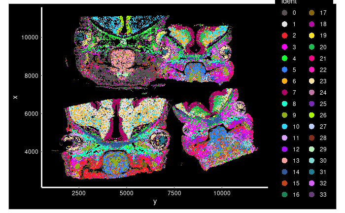

```r
DefaultBoundary(xenium.obj.crop[["fov"]]) <- "segmentation"
ImageDimPlot(xenium.obj, fov = "fov", cols = "polychrome", axes = TRUE)
```

Now, we can generate the Loupe file from the Seurat object.

```r
# Gene Expression RNA assay
assay <- xenium.obj[["Xenium"]]
# get counts matrix from either the old or newer formats of assay
counts <- counts_matrix_from_assay(assay)
# get clusters from the Seurat object
clusters <- select_clusters(xenium.obj)
# get projections from the Seurat object
projections <- select_projections(xenium.obj)
# get morphologies from the Seurat object
morph <- xenium.obj@images[["fov"]]@boundaries[["centroids"]]@coords %>% as.matrix()
rownames(morph) <- xenium.obj@images[["fov"]]@boundaries[["centroids"]]@cells
# add the morphologies to the projections
projections <- c(projections, morph = list(morph))
# get the barcodes from the counts matrix
barcodes <- colnames(counts)
barcode_count <- length(barcodes)
# validate the data
loupeR:::validate_count_mat(counts)
```

```
$success
[1] TRUE

$msg
NULL
```

```r
loupeR:::validate_clusters(clusters, barcode_count)
```

```
$success
[1] TRUE

$msg
NULL
```

```r
loupeR:::validate_projections(projections, barcode_count)
```

```
$success
[1] TRUE

$msg
NULL
```

```r
# convert the count matrix, clusters, and projections into a Loupe file
if(!dir.exists("./00.WZY_Res")){
  dir.create("./00.WZY_Res")
}
create_loupe(
  counts,
  clusters = clusters,
  projections = projections,
  force = TRUE,
  output_dir = "./00.WZY_Res",
  output_name = "WZY_Res.cloupe",
  feature_ids = NULL,
  executable_path = NULL,
  seurat_obj_version = NULL
)
```

```
2024/10/08 19:36:49 validating count matrix
2024/10/08 19:36:53 validating clusters
2024/10/08 19:36:53 validating projections
2024/10/08 19:36:53 creating temporary hdf5 file: /tmp/RtmpWajG3H/file6617b5e861051.h5
2024/10/08 19:37:06 invoking louper executable
2024/10/08 19:37:06 running command: "/home/ubuntu4/.local/share/R/loupeR/louper create --input='/tmp/RtmpWajG3H/file6617b5e861051.h5' --output='/mnt/md0/NIH_project/visium_HD/00.WZY_Res/WZY_Res.cloupe.cloupe' --force"
2024/10/08 19:37:06 validating input file: /tmp/RtmpWajG3H/file6617b5e861051.h5
2024/10/08 19:37:09 initializing loupe file: /tmp/787968106.cloupe
2024/10/08 19:37:09 converting count matrix
2024/10/08 19:38:19 converting projections
2024/10/08 19:38:19 converting clusters
2024/10/08 19:38:19 finished loupe file: /tmp/787968106.cloupe
2024/10/08 19:38:19 copying loupe file to: /mnt/md0/NIH_project/visium_HD/00.WZY_Res/WZY_Res.cloupe.cloupe
```

Finishing and clean

```r
# Save the Seurat object
saveRDS(xenium.obj, file = "xenium.obj.rds")
# Clean up
rm(
  # Environments variables
  u, url, attemp, attempt, attempt_max, list.of.packages.Bio, list.of.packages, new.packages, new.packages.Bio,
  # Exported AnnData files from Jupyter Notebook
  centroids, matrix, microns, segmentations, CellKeep, GeneKeep, centroid_cells, matrix_cells, common_cells,
  # For Seurat Objects
  data, segmentations.data, segmentation_cells, type, fov, has_dt, outs, num_cells,
  # For LoupeR
  assay, barcode_count, barcodes, BarcodesNeed, new_barcodes, pb, morph, projections, clusters, coords, counts
)
```

```r
rm(xenium.obj)
gc()
```

```
             used    (Mb) gc trigger    (Mb)    max used    (Mb)
Ncells   21967499  1173.2   51929490  2773.4    51929490  2773.4
Vcells 2384421472 18191.7 8989963373 68588.0 11237029801 85731.8
```

```r
save.image(file = ".RData")
```

# Supplementary

```r
# Export Seurat object to cloupe file
xenium.obj.crop <- readRDS(file = "xenium.obj.crop.rds")
# Gene Expression RNA assay
assay <- xenium.obj.crop[["Xenium"]]
# get counts matrix from either the old or newer formats of assay
counts <- counts_matrix_from_assay(assay)
# get clusters from the Seurat object
clusters <- select_clusters(xenium.obj.crop)
# get projections from the Seurat object
projections <- select_projections(xenium.obj.crop)
# get morphologies from the Seurat object
morph <- xenium.obj.crop@images[["fov"]]@boundaries[["centroids"]]@coords %>% as.matrix()
rownames(morph) <- xenium.obj.crop@images[["fov"]]@boundaries[["centroids"]]@cells
# add the morphologies to the projections
projections <- c(projections, morph = list(morph))
# get the barcodes from the counts matrix
barcodes <- colnames(counts)
barcode_count <- length(barcodes)
# validate the data
loupeR:::validate_count_mat(counts)
```

```
$success
[1] TRUE

$msg
NULL
```

```r
loupeR:::validate_clusters(clusters, barcode_count)
```

```
$success
[1] TRUE

$msg
NULL
```

```r
loupeR:::validate_projections(projections, barcode_count)
```

```
$success
[1] TRUE

$msg
NULL
```

```r
# convert the count matrix, clusters, and projections into a Loupe file
if(!dir.exists("./00.WZY_Res")){
  dir.create("./00.WZY_Res")
}
create_loupe(
  counts,
  clusters = clusters,
  projections = projections,
  force = TRUE,
  output_dir = "./00.WZY_Res",
  output_name = "WZY_Res.crop",
  feature_ids = NULL,
  executable_path = NULL,
  seurat_obj_version = NULL
)
```

```
2024/10/11 16:36:34 validating count matrix
2024/10/11 16:36:35 validating clusters
2024/10/11 16:36:35 validating projections
2024/10/11 16:36:35 creating temporary hdf5 file: /tmp/Rtmp12A0C9/file4d704330c2bdf.h5
2024/10/11 16:36:36 invoking louper executable
2024/10/11 16:36:36 running command: "/home/ubuntu4/.local/share/R/loupeR/louper create --input='/tmp/Rtmp12A0C9/file4d704330c2bdf.h5' --output='./00.WZY_Res/WZY_Res.crop.cloupe' --force"
2024/10/11 16:36:36 validating input file: /tmp/Rtmp12A0C9/file4d704330c2bdf.h5
2024/10/11 16:36:39 initializing loupe file: /tmp/1690011079.cloupe
2024/10/11 16:36:39 converting count matrix
2024/10/11 16:36:42 converting projections
2024/10/11 16:36:42 converting clusters
2024/10/11 16:36:42 finished loupe file: /tmp/1690011079.cloupe
2024/10/11 16:36:42 copying loupe file to: ./00.WZY_Res/WZY_Res.crop.cloupe
```

```r
rm(
  assay, counts, clusters, projections, morph,
  barcodes, barcode_count, xenium.obj.crop
)
gc()
```

```
            used   (Mb) gc trigger   (Mb)   max used   (Mb)
Ncells  16501741  881.3   46103900 2462.3   46103900 2462.3
Vcells 409891780 3127.3 1057001549 8064.3 1057001513 8064.3
```